# modelin_forDSM_RANst

## ns5

RANst ProfileC ns5 15

```r
mn="All_pRANst_ProfileC_NS5_pen15"

shpPoint<-readOGR(paste(point_shp_folder,mn,".shp",sep = "")) ###
sampData <- extract(covStack, shpPoint, sp = TRUE,method = "simple")

sampData<-sampData@data

sampData<-sampData[sampData$soilID %in% soil_type,]

sampData<-na.omit(sampData)

print(dim(sampData))
```

```
## [1] 339  10
```

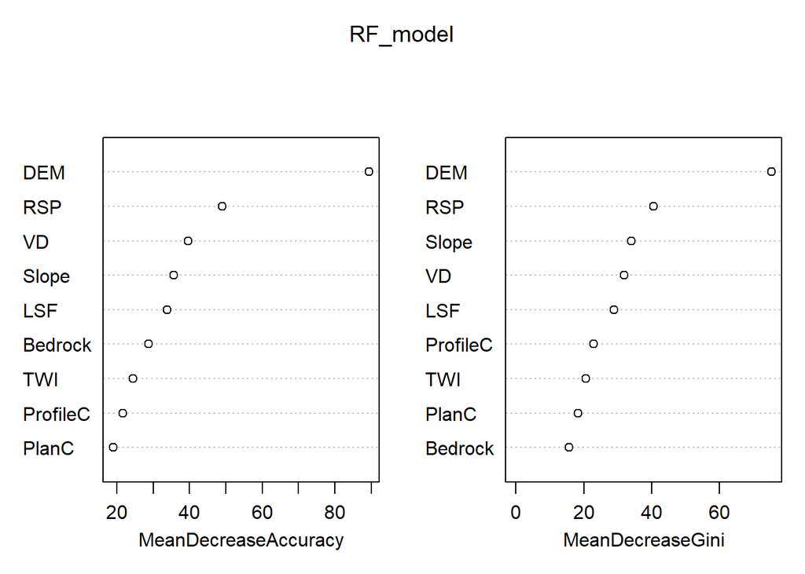

```r
sampleNum_dict[mn]<-nrow(sampData)

sampData$Bedrock<- droplevels(as.factor(sampData$Bedrock))
sampData$soilID<- droplevels(as.factor(sampData$soilID))

RF_model<-randomForest(soilID ~.,data = sampData,
                       importance = TRUE, proximity = FALSE,
                       ntree=1000,type="classification")

varImpPlot(RF_model)
```

```r
print(RF_model)
```

```
##
## Call:
##  randomForest(formula = soilID ~ ., data = sampData, importance = TRUE,      proximity = FALSE, ntree = 1000, type = "classification")
##                Type of random forest: classification
##                      Number of trees: 1000
## No. of variables tried at each split: 3
##
##         OOB estimate of  error rate: 33.63%
## Confusion matrix:
##     1 20 21 23  3 30 31 501 502 503  7 class.error
## 1   0  0  0  0  1  0  0   0   0   0  0   1.0000000
## 20  0 21  6  0  0  0  0   1   0  14  4   0.5434783
## 21  0  5 13  0  0  0  0   1   1   3  0   0.4347826
## 23  0  0  0 14  0  1  2   0   0   9  2   0.5000000
## 3   0  0  0  0 11  0  0   7   0   0  0   0.3888889
## 30  0  0  0  3  0  2  3   0   0   1  0   0.7777778
## 31  0  0  0  5  0  0  9   0   0   0  0   0.3571429
## 501 0  0  0  0  6  0  0  49   0   0  4   0.1694915
## 502 0  2  2  0  0  0  0   1   2   0  0   0.7142857
## 503 0  8  0  4  0  0  0   0   0  66  4   0.1951220
## 7   0  3  1  1  0  1  0   3   0   5 38   0.2692308
```

```r
map_RF <- predict(covStack, RF_model, paste(result_tif_folder,mn,".tif",sep=""),
                  format = "GTiff", datatype = "FLT4S", overwrite = TRUE)

rm("mn","shpPoint","sampData","RF_model","map_RF")
```

RANst ProfileC ns5 30

```r
mn="All_pRANst_ProfileC_NS5_pen30"

shpPoint<-readOGR(paste(point_shp_folder,mn,".shp",sep = "")) ###
sampData <- extract(covStack, shpPoint, sp = TRUE,method = "simple")

sampData<-sampData@data

sampData<-sampData[sampData$soilID %in% soil_type,]

sampData<-na.omit(sampData)

print(dim(sampData))
```

```
## [1] 638  10
```

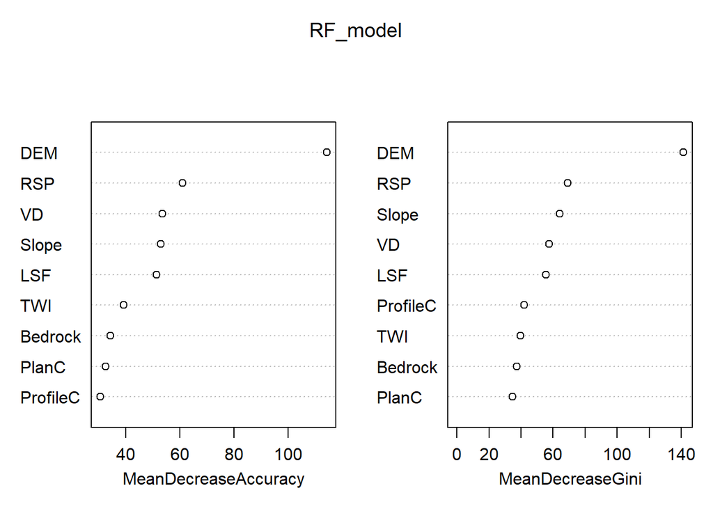

```r
sampleNum_dict[mn]<-nrow(sampData)

sampData$Bedrock<- droplevels(as.factor(sampData$Bedrock))
sampData$soilID<- droplevels(as.factor(sampData$soilID))

RF_model<-randomForest(soilID ~.,data = sampData,
                       importance = TRUE, proximity = FALSE,
                       ntree=1000,type="classification")

varImpPlot(RF_model)
```

```r
print(RF_model)
```

```
##
## Call:
##  randomForest(formula = soilID ~ ., data = sampData, importance = TRUE,      proximity = FALSE, ntree = 1000, type = "classification")
##                Type of random forest: classification
##                      Number of trees: 1000
## No. of variables tried at each split: 3
##
##         OOB estimate of  error rate: 27.59%
## Confusion matrix:
##     1 20 21 23  3 30 31 501 502 503  7 class.error
## 1   3  0  0  0  1  0  0   0   0   0  0   0.2500000
## 20  0 56  8  0  0  0  0   2   0  16  2   0.3333333
## 21  0 22  8  0  0  0  0   0   1   3  1   0.7714286
## 23  0  0  0 35  0  1  4   0   0  10  3   0.3396226
## 3   1  0  0  0 24  0  0  10   0   0  0   0.3142857
## 30  0  0  0  5  0  6  1   0   0   2  1   0.6000000
## 31  0  0  0  3  0  1 23   0   0   0  0   0.1481481
## 501 0  0  0  0 10  0  0 100   0   0  7   0.1452991
## 502 0  2  0  0  0  0  0   2   7   0  3   0.5000000
## 503 0  9  1  8  0  0  0   1   0 130  9   0.1772152
## 7   0  4  0  0  0  1  0  10   1  10 70   0.2708333
```

```r
map_RF <- predict(covStack, RF_model, paste(result_tif_folder,mn,".tif",sep=""),
                  format = "GTiff", datatype = "FLT4S", overwrite = TRUE)

rm("mn","shpPoint","sampData","RF_model","map_RF")
```

RANst ProfileC ns5 45

```r
mn="All_pRANst_ProfileC_NS5_pen45"

shpPoint<-readOGR(paste(point_shp_folder,mn,".shp",sep = "")) ###
sampData <- extract(covStack, shpPoint, sp = TRUE,method = "simple")

sampData<-sampData@data

sampData<-sampData[sampData$soilID %in% soil_type,]

sampData<-na.omit(sampData)

print(dim(sampData))
```

```
## [1] 936  10
```

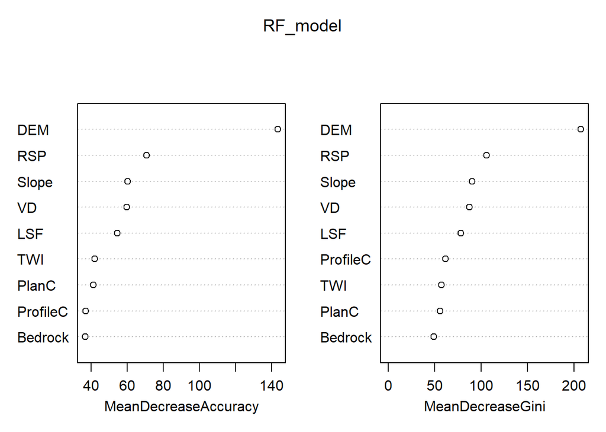

```r
sampleNum_dict[mn]<-nrow(sampData)

sampData$Bedrock<- droplevels(as.factor(sampData$Bedrock))
sampData$soilID<- droplevels(as.factor(sampData$soilID))

RF_model<-randomForest(soilID ~.,data = sampData,
                       importance = TRUE, proximity = FALSE,
                       ntree=1000,type="classification")

varImpPlot(RF_model)
```

```r
print(RF_model)
```

```
##
## Call:
##  randomForest(formula = soilID ~ ., data = sampData, importance = TRUE,      proximity = FALSE, ntree = 1000, type = "classification")
##                Type of random forest: classification
##                      Number of trees: 1000
## No. of variables tried at each split: 3
##
##         OOB estimate of  error rate: 28.74%
## Confusion matrix:
##     1 20 21 23  3 30 31 501 502 503   7 class.error
## 1   2  0  0  0  3  0  0   0   0   0   0   0.6000000
## 20  0 65 13  0  0  1  0   1   0  29  12   0.4628099
## 21  0 14 25  0  0  0  0   0   2   7   0   0.4791667
## 23  0  0  0 47  0  5  6   0   0  17   3   0.3974359
## 3   2  0  0  0 36  0  0  14   0   0   0   0.3076923
## 30  0  0  0  6  0  6  6   0   0   0   4   0.7272727
## 31  0  0  0  9  0  2 28   0   0   2   0   0.3170732
## 501 0  0  0  0 17  0  0 146   0   0  12   0.1657143
## 502 0  2  1  0  0  0  0   2  14   0   1   0.3000000
## 503 0 17  4  8  0  0  1   0   0 195  10   0.1702128
## 7   0 10  0  0  0  2  0  12   0  12 103   0.2589928
```

```r
map_RF <- predict(covStack, RF_model, paste(result_tif_folder,mn,".tif",sep=""),
                  format = "GTiff", datatype = "FLT4S", overwrite = TRUE)

rm("mn","shpPoint","sampData","RF_model","map_RF")
```

## ns7

RANst ProfileC ns7 15

```r
mn="All_pRANst_ProfileC_NS7_pen15"

shpPoint<-readOGR(paste(point_shp_folder,mn,".shp",sep = "")) ###
sampData <- extract(covStack, shpPoint, sp = TRUE,method = "simple")

sampData<-sampData@data

sampData<-sampData[sampData$soilID %in% soil_type,]

sampData<-na.omit(sampData)

print(dim(sampData))
```

```
## [1] 122  10
```

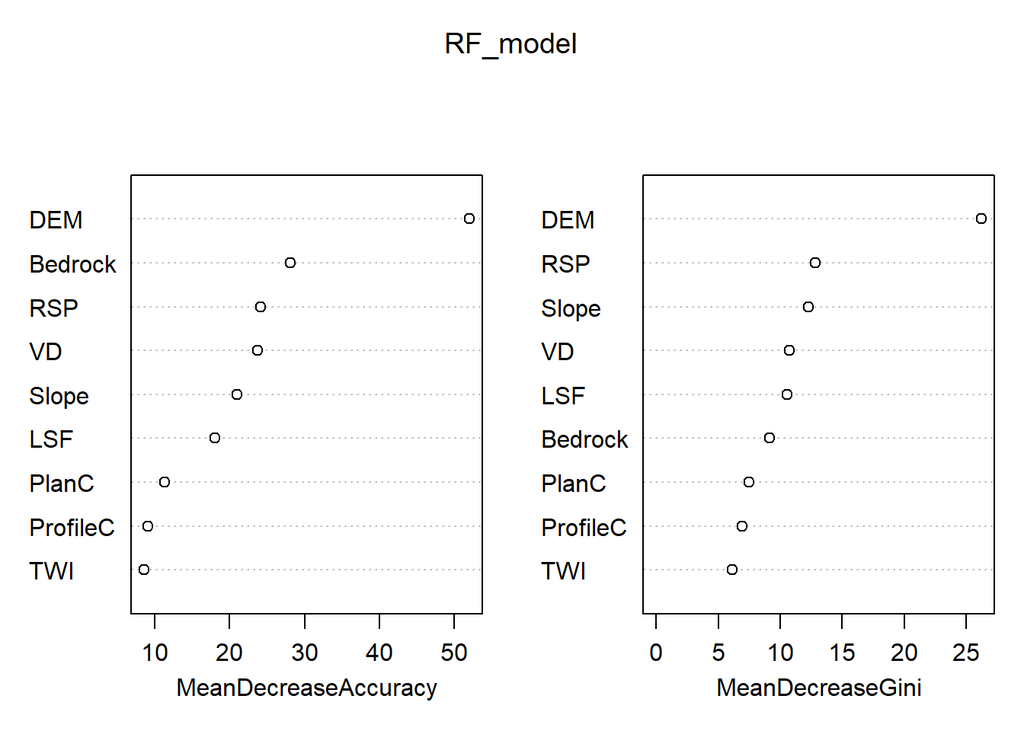

```r
sampleNum_dict[mn]<-nrow(sampData)

sampData$Bedrock<- droplevels(as.factor(sampData$Bedrock))
sampData$soilID<- droplevels(as.factor(sampData$soilID))

RF_model<-randomForest(soilID ~.,data = sampData,
                       importance = TRUE, proximity = FALSE,
                       ntree=1000,type="classification")

varImpPlot(RF_model)
```

```r
print(RF_model)
```

```
##
## Call:
##  randomForest(formula = soilID ~ ., data = sampData, importance = TRUE,      proximity = FALSE, ntree = 1000, type = "classification")
##                Type of random forest: classification
##                      Number of trees: 1000
## No. of variables tried at each split: 3
##
##         OOB estimate of  error rate: 43.44%
## Confusion matrix:
##     1 20 21 23 3 30 31 501 502 503  7 class.error
## 1   0  0  0  0 1  0  0   0   0   0  0   1.0000000
## 20  0  4  2  0 0  0  0   1   1   5  4   0.7647059
## 21  0  1  3  0 0  0  0   0   0   0  0   0.2500000
## 23  0  0  0  2 0  0  3   0   0   5  0   0.8000000
## 3   0  0  0  0 6  0  0   0   0   0  0   0.0000000
## 30  0  0  0  2 0  0  0   0   0   0  1   1.0000000
## 31  0  0  0  3 0  0  1   0   0   0  0   0.7500000
## 501 0  1  0  0 2  0  0  19   0   0  2   0.2083333
## 502 0  1  0  0 0  0  0   0   2   0  1   0.5000000
## 503 0  3  0  2 0  0  0   0   0  22  2   0.2413793
## 7   0  3  0  1 0  0  0   2   0   4 10   0.5000000
```

```r
map_RF <- predict(covStack, RF_model, paste(result_tif_folder,mn,".tif",sep=""),
                  format = "GTiff", datatype = "FLT4S", overwrite = TRUE)

rm("mn","shpPoint","sampData","RF_model","map_RF")
```

RANst ProfileC ns7 30

```r
mn="All_pRANst_ProfileC_NS7_pen30"

shpPoint<-readOGR(paste(point_shp_folder,mn,".shp",sep = "")) ###
sampData <- extract(covStack, shpPoint, sp = TRUE,method = "simple")

sampData<-sampData@data

sampData<-sampData[sampData$soilID %in% soil_type,]

sampData<-na.omit(sampData)

print(dim(sampData))
```

```
## [1] 215  10
```

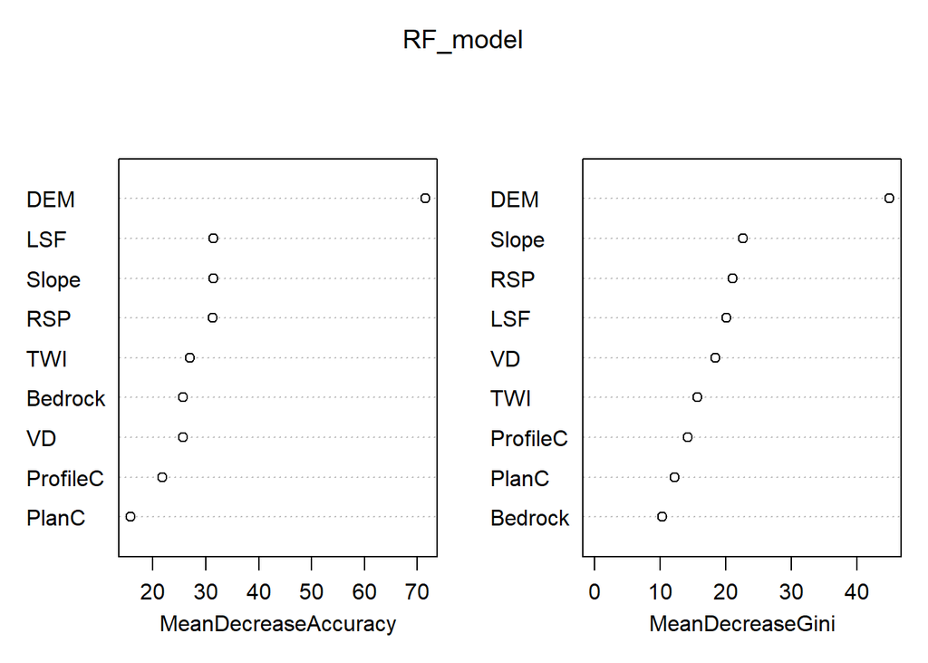

```r
sampleNum_dict[mn]<-nrow(sampData)

sampData$Bedrock<- droplevels(as.factor(sampData$Bedrock))
sampData$soilID<- droplevels(as.factor(sampData$soilID))

RF_model<-randomForest(soilID ~.,data = sampData,
                       importance = TRUE, proximity = FALSE,
                       ntree=1000,type="classification")

varImpPlot(RF_model)
```

```r
print(RF_model)
```

```
##
## Call:
##  randomForest(formula = soilID ~ ., data = sampData, importance = TRUE,      proximity = FALSE, ntree = 1000, type = "classification")
##                Type of random forest: classification
##                      Number of trees: 1000
## No. of variables tried at each split: 3
##
##         OOB estimate of  error rate: 33.49%
## Confusion matrix:
##     1 20 21 23 3 30 31 501 502 503  7 class.error
## 1   0  0  0  0 1  0  0   0   0   0  0   1.0000000
## 20  0 14  1  0 0  0  0   0   0   7  3   0.4400000
## 21  0  4  2  0 0  0  0   0   0   1  0   0.7142857
## 23  0  0  0 10 0  2  0   0   0   3  3   0.4444444
## 3   1  0  0  0 7  0  0   4   0   0  0   0.4166667
## 30  0  0  0  3 0  0  1   0   0   0  0   1.0000000
## 31  0  0  0  1 0  0  5   0   0   1  0   0.2857143
## 501 0  0  0  0 2  0  0  40   0   0  5   0.1489362
## 502 0  1  0  0 0  0  0   1   3   0  1   0.5000000
## 503 0  4  0  3 0  0  0   0   0  44  2   0.1698113
## 7   0  6  0  3 0  0  0   6   0   2 18   0.4857143
```

```r
map_RF <- predict(covStack, RF_model, paste(result_tif_folder,mn,".tif",sep=""),
                  format = "GTiff", datatype = "FLT4S", overwrite = TRUE)

rm("mn","shpPoint","sampData","RF_model","map_RF")
```

RANst ProfileC ns7 45

```r
mn="All_pRANst_ProfileC_NS7_pen45"

shpPoint<-readOGR(paste(point_shp_folder,mn,".shp",sep = "")) ###
sampData <- extract(covStack, shpPoint, sp = TRUE,method = "simple")

sampData<-sampData@data

sampData<-sampData[sampData$soilID %in% soil_type,]

sampData<-na.omit(sampData)

print(dim(sampData))
```

```
## [1] 307  10
```

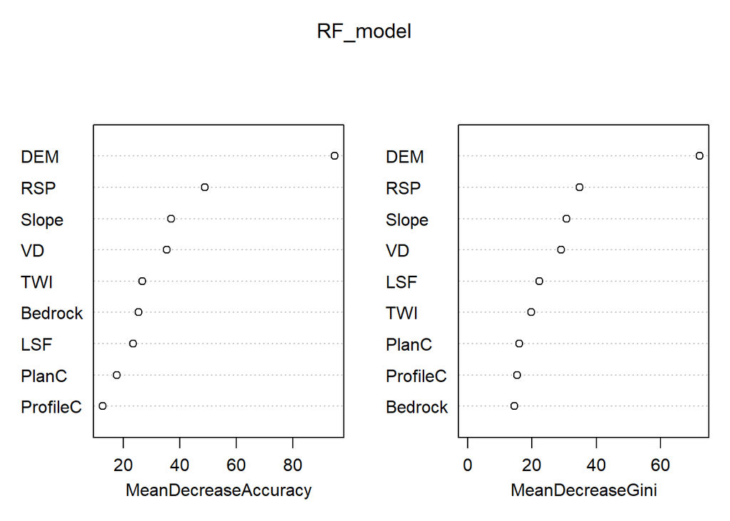

```r
sampleNum_dict[mn]<-nrow(sampData)

sampData$Bedrock<- droplevels(as.factor(sampData$Bedrock))
sampData$soilID<- droplevels(as.factor(sampData$soilID))

RF_model<-randomForest(soilID ~.,data = sampData,
                       importance = TRUE, proximity = FALSE,
                       ntree=1000,type="classification")

varImpPlot(RF_model)
```

```r
print(RF_model)
```

```
##
## Call:
##  randomForest(formula = soilID ~ ., data = sampData, importance = TRUE,      proximity = FALSE, ntree = 1000, type = "classification")
##                Type of random forest: classification
##                      Number of trees: 1000
## No. of variables tried at each split: 3
##
##         OOB estimate of  error rate: 32.9%
## Confusion matrix:
##     1 20 21 23  3 30 31 501 502 503  7 class.error
## 1   1  0  0  0  1  0  0   0   0   0  0   0.5000000
## 20  0 10  2  1  0  0  0   1   1  11  5   0.6774194
## 21  0  6  0  0  0  0  0   0   0   2  0   1.0000000
## 23  0  1  0 12  0  1  4   0   0   8  0   0.5384615
## 3   0  0  0  0 12  0  0   6   0   0  0   0.3333333
## 30  0  0  0  4  0  0  0   0   0   0  1   1.0000000
## 31  0  0  0  7  0  0  4   0   0   0  0   0.6363636
## 501 0  0  0  0  6  0  0  62   0   0  2   0.1142857
## 502 0  1  0  0  0  0  0   2   5   0  0   0.3750000
## 503 0  5  2  4  0  0  0   0   0  65  3   0.1772152
## 7   0  2  0  2  0  0  0   5   0   5 35   0.2857143
```

```r
map_RF <- predict(covStack, RF_model, paste(result_tif_folder,mn,".tif",sep=""),
                  format = "GTiff", datatype = "FLT4S", overwrite = TRUE)

rm("mn","shpPoint","sampData","RF_model","map_RF")
```

# TWI -ok

## ns3

RANst TWI ns3 15

```r
mn="All_pRANst_TWI_NS3_pen15"

shpPoint<-readOGR(paste(point_shp_folder,mn,".shp",sep = "")) ###
sampData <- extract(covStack, shpPoint, sp = TRUE,method = "simple")

sampData<-sampData@data

sampData<-sampData[sampData$soilID %in% soil_type,]

sampData<-na.omit(sampData)

print(dim(sampData))
```

```
## [1] 982  10
```

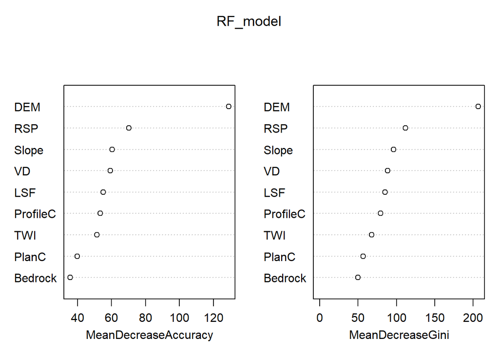

```r
sampleNum_dict[mn]<-nrow(sampData)

sampData$Bedrock<- droplevels(as.factor(sampData$Bedrock))
sampData$soilID<- droplevels(as.factor(sampData$soilID))

RF_model<-randomForest(soilID ~.,data = sampData,
                       importance = TRUE, proximity = FALSE,
                       ntree=1000,type="classification")

varImpPlot(RF_model)
```

```r
print(RF_model)
```

```
##
## Call:
##  randomForest(formula = soilID ~ ., data = sampData, importance = TRUE,      proximity = FALSE, ntree = 1000, type = "classification")
##                Type of random forest: classification
##                      Number of trees: 1000
## No. of variables tried at each split: 3
##
##         OOB estimate of  error rate: 28.41%
## Confusion matrix:
##     1 20 21 23  3 30 31 501 502 503   7 class.error
## 1   4  0  0  0  1  0  0   0   0   0   0   0.2000000
## 20  0 99 12  3  0  0  0   2   1  23  11   0.3443709
## 21  0 25 26  0  0  0  0   0   1   3   0   0.5272727
## 23  0  3  0 67  0  4  3   0   0  20   4   0.3366337
## 3   1  0  0  0 32  0  0  17   0   0   0   0.3600000
## 30  0  0  0  9  0 17  3   0   0   1   3   0.4848485
## 31  0  0  0  9  0  2 30   0   0   1   0   0.2857143
## 501 0  1  0  0 13  0  0 135   1   0   7   0.1401274
## 502 0  7  2  0  0  0  0   2   8   1   0   0.6000000
## 503 0 17  4 21  0  2  0   1   0 178   5   0.2192982
## 7   0 12  0  3  0  2  0  10   0   6 107   0.2357143
```

```r
map_RF <- predict(covStack, RF_model, paste(result_tif_folder,mn,".tif",sep=""),
                  format = "GTiff", datatype = "FLT4S", overwrite = TRUE)

rm("mn","shpPoint","sampData","RF_model","map_RF")
```

RANst TWI ns3 30

```r
mn="All_pRANst_TWI_NS3_pen30"

shpPoint<-readOGR(paste(point_shp_folder,mn,".shp",sep = "")) ###
sampData <- extract(covStack, shpPoint, sp = TRUE,method = "simple")

sampData<-sampData@data

sampData<-sampData[sampData$soilID %in% soil_type,]

sampData<-na.omit(sampData)

print(dim(sampData))
```

```
## [1] 1918   10
```

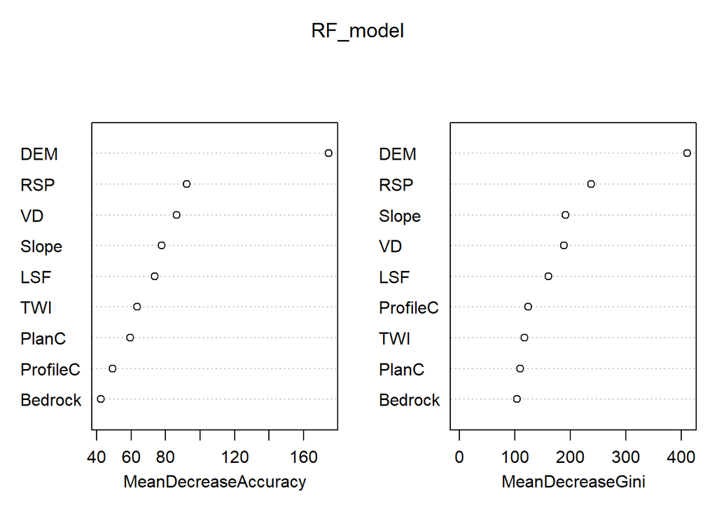

```r
sampleNum_dict[mn]<-nrow(sampData)

sampData$Bedrock<- droplevels(as.factor(sampData$Bedrock))
sampData$soilID<- droplevels(as.factor(sampData$soilID))

RF_model<-randomForest(soilID ~.,data = sampData,
                       importance = TRUE, proximity = FALSE,
                       ntree=1000,type="classification")

varImpPlot(RF_model)
```

```r
print(RF_model)
```

```
##
## Call:
##  randomForest(formula = soilID ~ ., data = sampData, importance = TRUE,      proximity = FALSE, ntree = 1000, type = "classification")
##                Type of random forest: classification
##                      Number of trees: 1000
## No. of variables tried at each split: 3
##
##         OOB estimate of  error rate: 27.74%
## Confusion matrix:
##     1  20 21  23  3 30 31 501 502 503   7 class.error
## 1   8   0  0   0  2  0  0   0   0   0   0   0.2000000
## 20  0 182 17   0  0  0  0   3   3  56  33   0.3809524
## 21  0  35 59   0  0  0  0   0   1   8   1   0.4326923
## 23  0   0  0 131  0  9  9   0   0  34  10   0.3212435
## 3   0   0  0   0 66  0  0  33   0   0   0   0.3333333
## 30  0   0  0  11  0 37  6   0   0   2   7   0.4126984
## 31  0   0  0  22  0  4 56   0   0   1   0   0.3253012
## 501 0   3  0   0 23  0  0 273   0   0  14   0.1277955
## 502 0   8  3   0  0  0  0   2  25   0   0   0.3421053
## 503 0  52  5  23  0  0  0   0   1 356  12   0.2071269
## 7   0  23  1   2  0  5  0  27   1  20 193   0.2904412
```

```r
map_RF <- predict(covStack, RF_model, paste(result_tif_folder,mn,".tif",sep=""),
                  format = "GTiff", datatype = "FLT4S", overwrite = TRUE)

rm("mn","shpPoint","sampData","RF_model","map_RF")
```

RANst TWI ns3 45

```r
mn="All_pRANst_TWI_NS3_pen45"

shpPoint<-readOGR(paste(point_shp_folder,mn,".shp",sep = "")) ###
sampData <- extract(covStack, shpPoint, sp = TRUE,method = "simple")

sampData<-sampData@data

sampData<-sampData[sampData$soilID %in% soil_type,]

sampData<-na.omit(sampData)

print(dim(sampData))
```

```
## [1] 2857   10
```

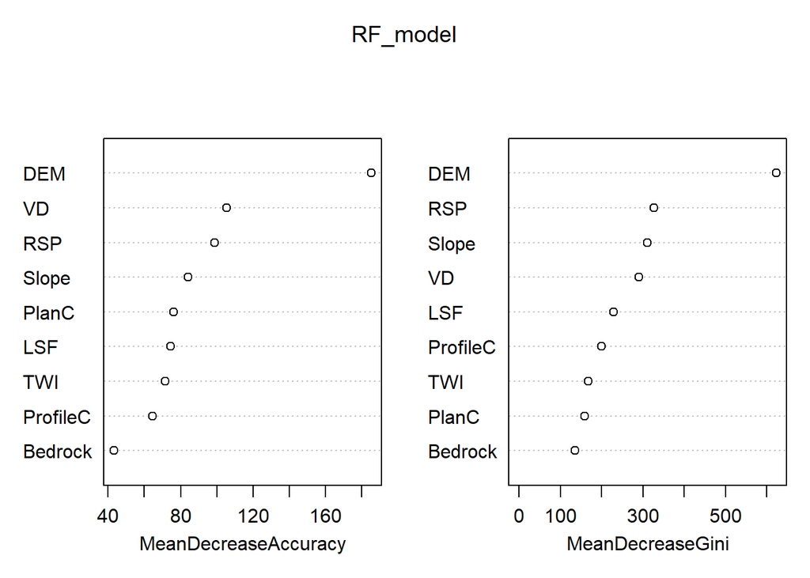

```r
sampleNum_dict[mn]<-nrow(sampData)

sampData$Bedrock<- droplevels(as.factor(sampData$Bedrock))
sampData$soilID<- droplevels(as.factor(sampData$soilID))

RF_model<-randomForest(soilID ~.,data = sampData,
                       importance = TRUE, proximity = FALSE,
                       ntree=1000,type="classification")

varImpPlot(RF_model)
```

```r
print(RF_model)
```

```
##
## Call:
##  randomForest(formula = soilID ~ ., data = sampData, importance = TRUE,      proximity = FALSE, ntree = 1000, type = "classification")
##                Type of random forest: classification
##                      Number of trees: 1000
## No. of variables tried at each split: 3
##
##         OOB estimate of  error rate: 24.68%
## Confusion matrix:
##      1  20 21  23   3 30  31 501 502 503   7 class.error
## 1   13   0  0   0   3  0   0   0   0   0   0  0.18750000
## 20   0 278 27   2   0  0   0   8   4  80  37  0.36238532
## 21   0  71 64   0   0  0   0   3   3  10   5  0.58974359
## 23   0   0  0 185   0 18   8   0   0  55  20  0.35314685
## 3    3   0  0   0 111  0   0  33   0   0   0  0.24489796
## 30   0   0  0  21   0 57   4   0   0   2   7  0.37362637
## 31   0   0  0  17   0  4 101   0   0   2   0  0.18548387
## 501  0   1  0   0  25  0   0 430   0   1  12  0.08315565
## 502  0   4  2   0   0  0   0   2  36   2   8  0.33333333
## 503  0  61  4  29   0  3   0   0   2 554  19  0.17559524
## 7    0  29  1   7   0  2   0  21   4  19 323  0.20443350
```

```r
map_RF <- predict(covStack, RF_model, paste(result_tif_folder,mn,".tif",sep=""),
                  format = "GTiff", datatype = "FLT4S", overwrite = TRUE)

rm("mn","shpPoint","sampData","RF_model","map_RF")
```

## ns5

RANst TWI ns5 15

```r
mn="All_pRANst_TWI_NS5_pen15"

shpPoint<-readOGR(paste(point_shp_folder,mn,".shp",sep = "")) ###
sampData <- extract(covStack, shpPoint, sp = TRUE,method = "simple")

sampData<-sampData@data

sampData<-sampData[sampData$soilID %in% soil_type,]

sampData<-na.omit(sampData)

print(dim(sampData))
```

```
## [1] 337  10
```

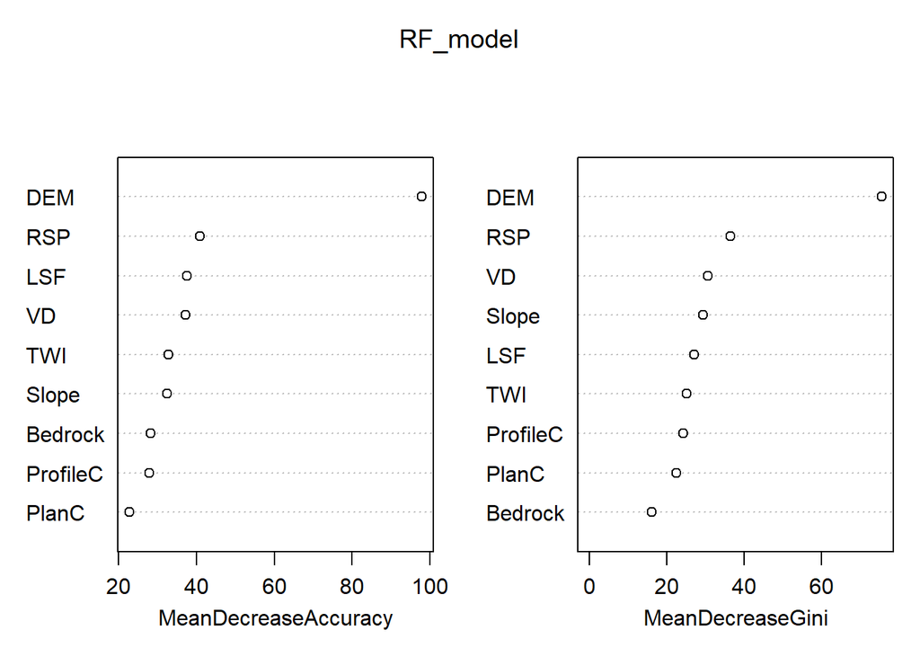

```r
sampleNum_dict[mn]<-nrow(sampData)

sampData$Bedrock<- droplevels(as.factor(sampData$Bedrock))
sampData$soilID<- droplevels(as.factor(sampData$soilID))

RF_model<-randomForest(soilID ~.,data = sampData,
                       importance = TRUE, proximity = FALSE,
                       ntree=1000,type="classification")

varImpPlot(RF_model)
```

```r
print(RF_model)
```

```
##
## Call:
##  randomForest(formula = soilID ~ ., data = sampData, importance = TRUE,      proximity = FALSE, ntree = 1000, type = "classification")
##                Type of random forest: classification
##                      Number of trees: 1000
## No. of variables tried at each split: 3
##
##         OOB estimate of  error rate: 32.94%
## Confusion matrix:
##     1 20 21 23  3 30 31 501 502 503  7 class.error
## 1   1  0  0  0  1  0  0   0   0   0  0   0.5000000
## 20  0 19  8  0  0  1  0   0   0   8  8   0.5681818
## 21  0 12  4  0  0  0  0   0   0   6  0   0.8181818
## 23  0  0  0 16  0  4  2   0   0   7  0   0.4482759
## 3   0  0  0  0 12  0  0   5   0   0  0   0.2941176
## 30  0  0  0  4  0  1  1   0   0   0  3   0.8888889
## 31  0  0  0  4  0  1  8   0   0   0  1   0.4285714
## 501 0  0  0  0  2  0  0  53   0   0  4   0.1016949
## 502 0  1  0  0  0  0  0   2   4   0  0   0.4285714
## 503 0  2  2  3  0  0  0   0   0  69  5   0.1481481
## 7   0  4  0  1  0  1  0   2   0   6 39   0.2641509
```

```r
map_RF <- predict(covStack, RF_model, paste(result_tif_folder,mn,".tif",sep=""),
                  format = "GTiff", datatype = "FLT4S", overwrite = TRUE)

rm("mn","shpPoint","sampData","RF_model","map_RF")
```

RANst TWI ns5 30

```r
mn="All_pRANst_TWI_NS5_pen30"

shpPoint<-readOGR(paste(point_shp_folder,mn,".shp",sep = "")) ###
sampData <- extract(covStack, shpPoint, sp = TRUE,method = "simple")

sampData<-sampData@data

sampData<-sampData[sampData$soilID %in% soil_type,]

sampData<-na.omit(sampData)

print(dim(sampData))
```

```
## [1] 633  10
```

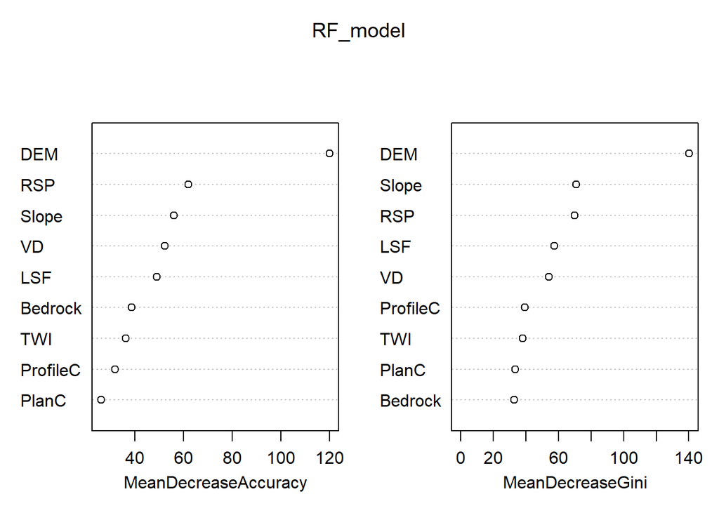

```r
sampleNum_dict[mn]<-nrow(sampData)

sampData$Bedrock<- droplevels(as.factor(sampData$Bedrock))
sampData$soilID<- droplevels(as.factor(sampData$soilID))

RF_model<-randomForest(soilID ~.,data = sampData,
                       importance = TRUE, proximity = FALSE,
                       ntree=1000,type="classification")

varImpPlot(RF_model)
```

```r
print(RF_model)
```

```
##
## Call:
##  randomForest(formula = soilID ~ ., data = sampData, importance = TRUE,      proximity = FALSE, ntree = 1000, type = "classification")
##                Type of random forest: classification
##                      Number of trees: 1000
## No. of variables tried at each split: 3
##
##         OOB estimate of  error rate: 31.28%
## Confusion matrix:
##     1 20 21 23  3 30 31 501 502 503  7 class.error
## 1   2  0  0  0  1  0  0   0   0   0  0   0.3333333
## 20  0 49  6  0  0  0  0   2   1  12 12   0.4024390
## 21  0 16 15  0  0  0  0   0   0   0  1   0.5312500
## 23  0  0  0 28  0  4  3   0   0  15  4   0.4814815
## 3   0  0  0  0 18  0  0  16   0   0  0   0.4705882
## 30  0  0  0  7  0  4  1   0   0   2  1   0.7333333
## 31  0  0  0  2  0  1 25   0   0   0  0   0.1071429
## 501 0  0  0  0  9  0  0 102   0   0  6   0.1282051
## 502 0  2  0  0  0  0  0   4   6   0  2   0.5714286
## 503 0 16  0 12  0  0  0   0   0 119  8   0.2322581
## 7   0  6  0  1  0  1  0  13   0  11 67   0.3232323
```

```r
map_RF <- predict(covStack, RF_model, paste(result_tif_folder,mn,".tif",sep=""),
                  format = "GTiff", datatype = "FLT4S", overwrite = TRUE)

rm("mn","shpPoint","sampData","RF_model","map_RF")
```

RANst TWI ns5 45

```r
mn="All_pRANst_TWI_NS5_pen45"

shpPoint<-readOGR(paste(point_shp_folder,mn,".shp",sep = "")) ###
sampData <- extract(covStack, shpPoint, sp = TRUE,method = "simple")

sampData<-sampData@data

sampData<-sampData[sampData$soilID %in% soil_type,]

sampData<-na.omit(sampData)

print(dim(sampData))
```

```
## [1] 933  10
```

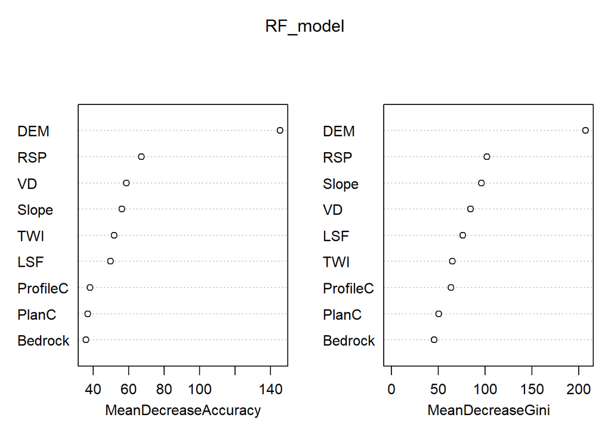

```r
sampleNum_dict[mn]<-nrow(sampData)

sampData$Bedrock<- droplevels(as.factor(sampData$Bedrock))
sampData$soilID<- droplevels(as.factor(sampData$soilID))

RF_model<-randomForest(soilID ~.,data = sampData,
                       importance = TRUE, proximity = FALSE,
                       ntree=1000,type="classification")

varImpPlot(RF_model)
```

```r
print(RF_model)
```

```
##
## Call:
##  randomForest(formula = soilID ~ ., data = sampData, importance = TRUE,      proximity = FALSE, ntree = 1000, type = "classification")
##                Type of random forest: classification
##                      Number of trees: 1000
## No. of variables tried at each split: 3
##
##         OOB estimate of  error rate: 27.44%
## Confusion matrix:
##     1 20 21 23  3 30 31 501 502 503   7 class.error
## 1   3  0  0  0  2  0  0   0   0   0   0   0.4000000
## 20  0 58 12  0  0  0  0   2   3  25  18   0.5084746
## 21  0 19 23  0  0  0  0   0   0   3   0   0.4888889
## 23  0  0  0 48  0  6  4   0   0  21   2   0.4074074
## 3   0  0  0  0 31  0  0  19   0   0   0   0.3800000
## 30  0  0  0 13  0  7  1   0   0   0   1   0.6818182
## 31  0  0  0  8  0  0 32   0   0   2   0   0.2380952
## 501 0  2  0  0  8  0  0 156   0   0   9   0.1085714
## 502 0  2  0  0  0  0  0   2  12   0   3   0.3684211
## 503 0 21  1 10  0  0  0   0   0 191   8   0.1731602
## 7   0  9  0  1  0  0  0  11   0   8 116   0.2000000
```

```r
map_RF <- predict(covStack, RF_model, paste(result_tif_folder,mn,".tif",sep=""),
                  format = "GTiff", datatype = "FLT4S", overwrite = TRUE)

rm("mn","shpPoint","sampData","RF_model","map_RF")
```

## ns7

RANst TWI ns7 15

```r
mn="All_pRANst_TWI_NS7_pen15"

shpPoint<-readOGR(paste(point_shp_folder,mn,".shp",sep = "")) ###
sampData <- extract(covStack, shpPoint, sp = TRUE,method = "simple")

sampData<-sampData@data

sampData<-sampData[sampData$soilID %in% soil_type,]

sampData<-na.omit(sampData)

print(dim(sampData))
```

```
## [1] 122  10
```

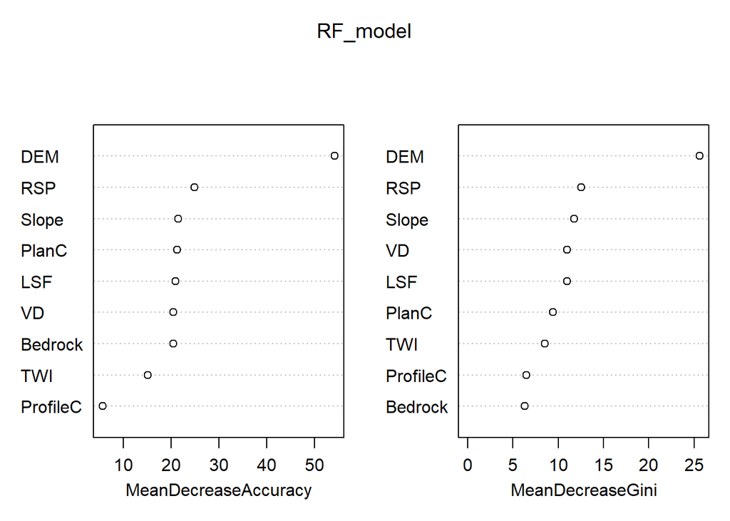

```r
sampleNum_dict[mn]<-nrow(sampData)

sampData$Bedrock<- droplevels(as.factor(sampData$Bedrock))
sampData$soilID<- droplevels(as.factor(sampData$soilID))

RF_model<-randomForest(soilID ~.,data = sampData,
                       importance = TRUE, proximity = FALSE,
                       ntree=1000,type="classification")

varImpPlot(RF_model)
```

```r
print(RF_model)
```

```
##
## Call:
##  randomForest(formula = soilID ~ ., data = sampData, importance = TRUE,      proximity = FALSE, ntree = 1000, type = "classification")
##                Type of random forest: classification
##                      Number of trees: 1000
## No. of variables tried at each split: 3
##
##         OOB estimate of  error rate: 40.16%
## Confusion matrix:
##     1 20 21 23 3 30 31 501 502 503  7 class.error
## 1   0  0  0  0 1  0  0   0   0   0  0   1.0000000
## 20  0  8  0  1 0  0  0   0   0   5  3   0.5294118
## 21  0  2  2  0 0  0  0   0   0   0  0   0.5000000
## 23  0  0  0  5 0  1  1   0   0   4  0   0.5454545
## 3   0  0  0  0 5  0  0   2   0   0  0   0.2857143
## 30  0  0  0  1 0  0  2   0   0   0  0   1.0000000
## 31  0  0  0  1 0  1  2   0   0   0  0   0.5000000
## 501 0  0  0  0 2  0  0  19   0   0  2   0.1739130
## 502 0  0  0  0 0  0  0   0   0   0  3   1.0000000
## 503 0  3  0  5 0  0  0   0   0  19  2   0.3448276
## 7   0  2  0  0 0  0  0   2   0   3 13   0.3500000
```

```r
map_RF <- predict(covStack, RF_model, paste(result_tif_folder,mn,".tif",sep=""),
                  format = "GTiff", datatype = "FLT4S", overwrite = TRUE)

rm("mn","shpPoint","sampData","RF_model","map_RF")
```

RANst TWI ns7 30

```r
mn="All_pRANst_TWI_NS7_pen30"

shpPoint<-readOGR(paste(point_shp_folder,mn,".shp",sep = "")) ###
sampData <- extract(covStack, shpPoint, sp = TRUE,method = "simple")

sampData<-sampData@data

sampData<-sampData[sampData$soilID %in% soil_type,]

sampData<-na.omit(sampData)

print(dim(sampData))
```

```
## [1] 216  10
```

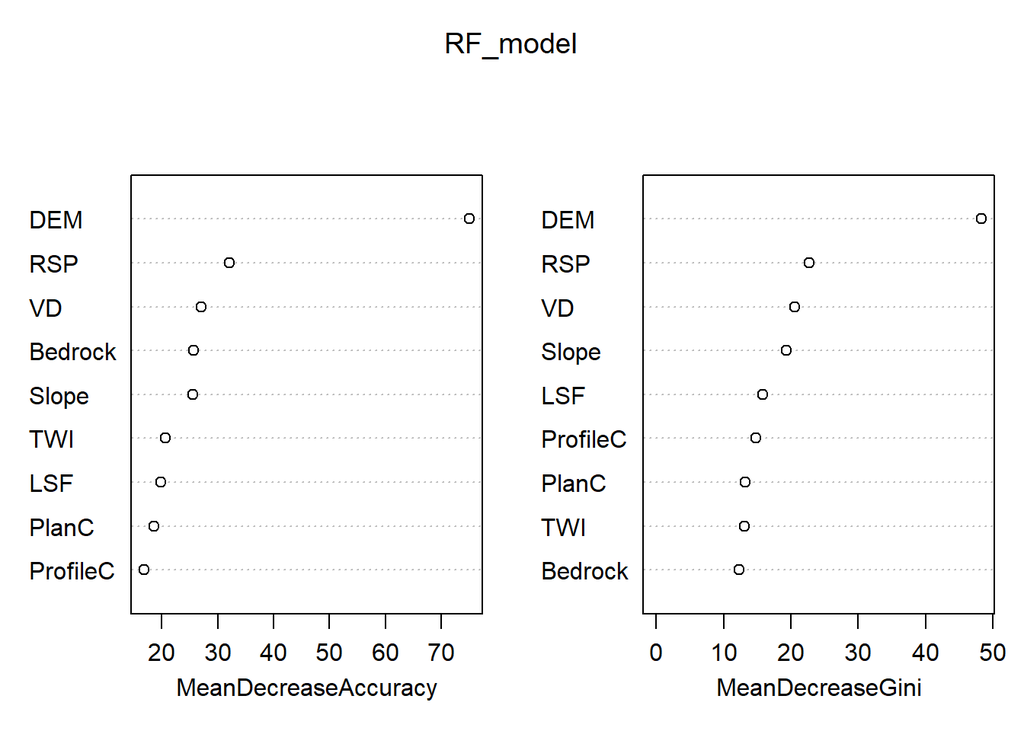

```r
sampleNum_dict[mn]<-nrow(sampData)

sampData$Bedrock<- droplevels(as.factor(sampData$Bedrock))
sampData$soilID<- droplevels(as.factor(sampData$soilID))

RF_model<-randomForest(soilID ~.,data = sampData,
                       importance = TRUE, proximity = FALSE,
                       ntree=1000,type="classification")

varImpPlot(RF_model)
```

```r
print(RF_model)
```

```
##
## Call:
##  randomForest(formula = soilID ~ ., data = sampData, importance = TRUE,      proximity = FALSE, ntree = 1000, type = "classification")
##                Type of random forest: classification
##                      Number of trees: 1000
## No. of variables tried at each split: 3
##
##         OOB estimate of  error rate: 32.41%
## Confusion matrix:
##     1 20 21 23 3 30 31 501 502 503  7 class.error
## 1   0  0  0  0 1  0  0   0   0   0  0   1.0000000
## 20  0 12  2  0 0  0  0   0   1   8  3   0.5384615
## 21  0  5  1  0 0  0  0   0   0   0  0   0.8333333
## 23  0  0  0 12 0  0  2   0   0   5  1   0.4000000
## 3   0  0  0  0 7  0  0   6   0   0  0   0.4615385
## 30  0  0  0  2 0  0  0   0   0   1  1   1.0000000
## 31  0  0  0  4 0  0  2   0   0   1  0   0.7142857
## 501 0  0  0  0 3  0  0  38   0   0  4   0.1555556
## 502 0  1  0  0 0  0  0   1   1   0  2   0.8000000
## 503 0  5  0  1 0  0  0   0   0  46  2   0.1481481
## 7   0  1  0  2 0  0  0   3   0   2 27   0.2285714
```

```r
map_RF <- predict(covStack, RF_model, paste(result_tif_folder,mn,".tif",sep=""),
                  format = "GTiff", datatype = "FLT4S", overwrite = TRUE)

rm("mn","shpPoint","sampData","RF_model","map_RF")
```

RANst TWI ns7 45

```r
mn="All_pRANst_TWI_NS7_pen45"

shpPoint<-readOGR(paste(point_shp_folder,mn,".shp",sep = "")) ###
sampData <- extract(covStack, shpPoint, sp = TRUE,method = "simple")

sampData<-sampData@data

sampData<-sampData[sampData$soilID %in% soil_type,]

sampData<-na.omit(sampData)

print(dim(sampData))
```

```
## [1] 310  10
```

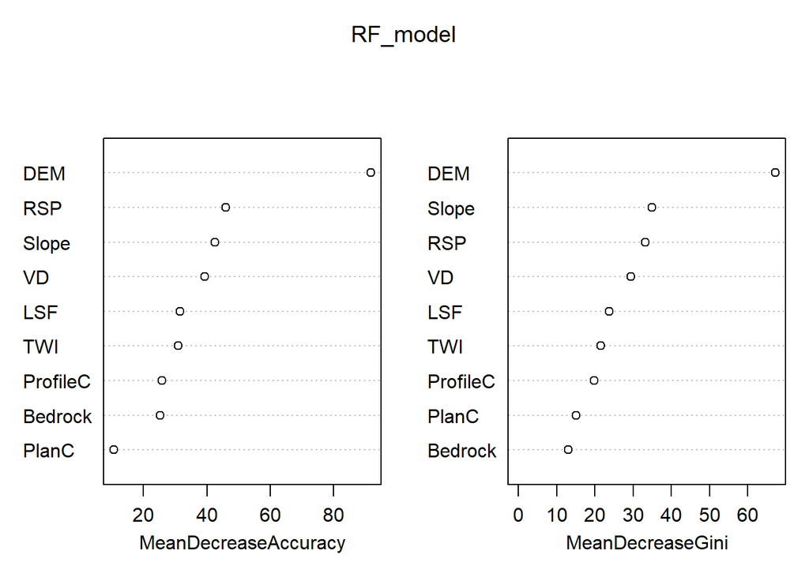

```r
sampleNum_dict[mn]<-nrow(sampData)

sampData$Bedrock<- droplevels(as.factor(sampData$Bedrock))
sampData$soilID<- droplevels(as.factor(sampData$soilID))

RF_model<-randomForest(soilID ~.,data = sampData,
                       importance = TRUE, proximity = FALSE,
                       ntree=1000,type="classification")

varImpPlot(RF_model)
```

```r
print(RF_model)
```

```
##
## Call:
##  randomForest(formula = soilID ~ ., data = sampData, importance = TRUE,      proximity = FALSE, ntree = 1000, type = "classification")
##                Type of random forest: classification
##                      Number of trees: 1000
## No. of variables tried at each split: 3
##
##         OOB estimate of  error rate: 33.23%
## Confusion matrix:
##     1 20 21 23  3 30 31 501 502 503  7 class.error
## 1   0  0  0  0  2  0  0   0   0   0  0   1.0000000
## 20  0 14  2  0  0  0  0   0   0  12  6   0.5882353
## 21  0  7  0  0  0  0  0   0   0   0  1   1.0000000
## 23  0  0  0 11  0  1  3   0   0  10  2   0.5925926
## 3   0  0  0  0 15  0  0   4   0   0  0   0.2105263
## 30  0  0  0  1  0  1  3   0   0   0  0   0.8000000
## 31  0  0  0  4  0  1  6   0   0   0  0   0.4545455
## 501 0  0  0  0  3  0  0  57   1   0  6   0.1492537
## 502 0  0  0  0  0  0  0   5   0   0  2   1.0000000
## 503 0  4  0  6  0  0  0   0   0  67  2   0.1518987
## 7   0  5  0  2  0  0  0   4   0   4 36   0.2941176
```

```r
map_RF <- predict(covStack, RF_model, paste(result_tif_folder,mn,".tif",sep=""),
                  format = "GTiff", datatype = "FLT4S", overwrite = TRUE)

rm("mn","shpPoint","sampData","RF_model","map_RF")
```

# LSF -ok

## ns3

RANst LSF ns3 15

```r
mn="All_pRANst_LSF_NS3_pen15"

shpPoint<-readOGR(paste(point_shp_folder,mn,".shp",sep = "")) ###
sampData <- extract(covStack, shpPoint, sp = TRUE,method = "simple")

sampData<-sampData@data

sampData<-sampData[sampData$soilID %in% soil_type,]

sampData<-na.omit(sampData)

print(dim(sampData))
```

```
## [1] 984  10
```

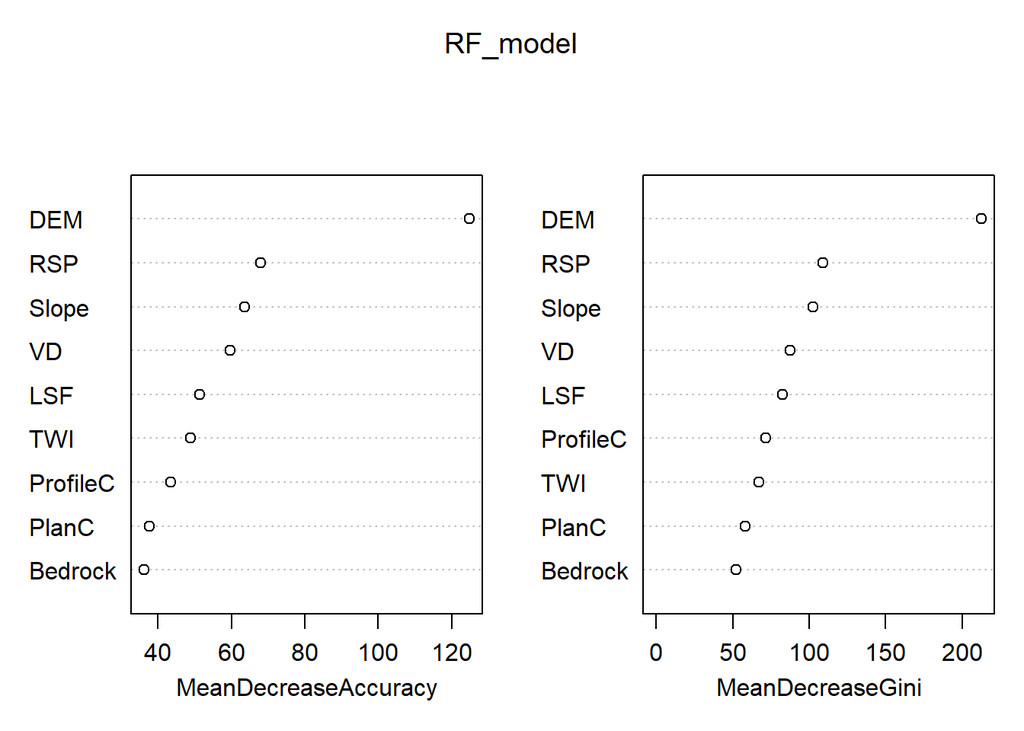

```r
sampleNum_dict[mn]<-nrow(sampData)

sampData$Bedrock<- droplevels(as.factor(sampData$Bedrock))
sampData$soilID<- droplevels(as.factor(sampData$soilID))

RF_model<-randomForest(soilID ~.,data = sampData,
                       importance = TRUE, proximity = FALSE,
                       ntree=1000,type="classification")

varImpPlot(RF_model)
```

```r
print(RF_model)
```

```
##
## Call:
##  randomForest(formula = soilID ~ ., data = sampData, importance = TRUE,      proximity = FALSE, ntree = 1000, type = "classification")
##                Type of random forest: classification
##                      Number of trees: 1000
## No. of variables tried at each split: 3
##
##         OOB estimate of  error rate: 30.69%
## Confusion matrix:
##     1 20 21 23  3 30 31 501 502 503  7 class.error
## 1   2  0  0  0  3  0  0   0   0   0  0  0.60000000
## 20  0 78 22  1  0  0  0   2   1  34 17  0.49677419
## 21  0 33 21  0  0  0  0   0   0   3  1  0.63793103
## 23  0  0  0 73  0  4  5   0   0  18  0  0.27000000
## 3   1  0  0  0 40  0  0  11   0   0  0  0.23076923
## 30  0  0  0 11  0 13  4   0   0   1  3  0.59375000
## 31  0  0  0 10  0  1 29   0   0   1  0  0.29268293
## 501 0  2  0  0  7  0  0 143   0   0  6  0.09493671
## 502 0  5  0  0  0  0  0   4  10   1  1  0.52380952
## 503 0 27  3 16  0  0  0   0   0 174  7  0.23348018
## 7   0 15  0  1  0  3  0   6   1  10 99  0.26666667
```

```r
map_RF <- predict(covStack, RF_model, paste(result_tif_folder,mn,".tif",sep=""),
                  format = "GTiff", datatype = "FLT4S", overwrite = TRUE)

rm("mn","shpPoint","sampData","RF_model","map_RF")
```

RANst LSF ns3 30

```r
mn="All_pRANst_LSF_NS3_pen30"

shpPoint<-readOGR(paste(point_shp_folder,mn,".shp",sep = "")) ###
sampData <- extract(covStack, shpPoint, sp = TRUE,method = "simple")

sampData<-sampData@data

sampData<-sampData[sampData$soilID %in% soil_type,]

sampData<-na.omit(sampData)

print(dim(sampData))
```

```
## [1] 1924   10
```

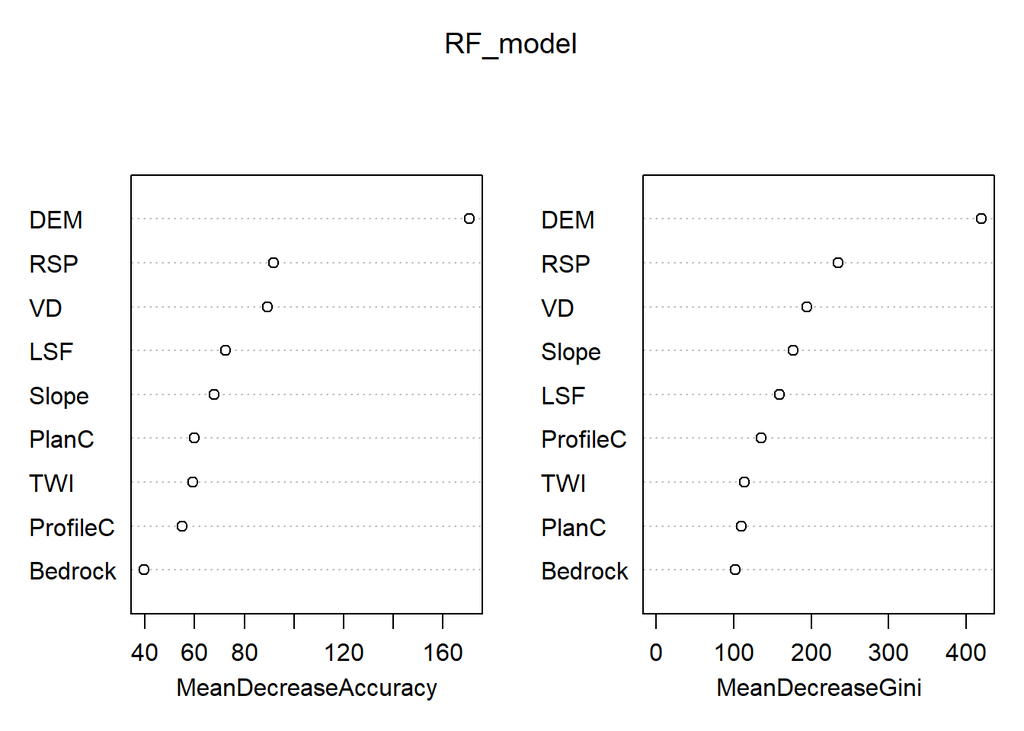

```r
sampleNum_dict[mn]<-nrow(sampData)

sampData$Bedrock<- droplevels(as.factor(sampData$Bedrock))
sampData$soilID<- droplevels(as.factor(sampData$soilID))

RF_model<-randomForest(soilID ~.,data = sampData,
                       importance = TRUE, proximity = FALSE,
                       ntree=1000,type="classification")

varImpPlot(RF_model)
```

```r
print(RF_model)
```

```
##
## Call:
##  randomForest(formula = soilID ~ ., data = sampData, importance = TRUE,      proximity = FALSE, ntree = 1000, type = "classification")
##                Type of random forest: classification
##                      Number of trees: 1000
## No. of variables tried at each split: 3
##
##         OOB estimate of  error rate: 26.98%
## Confusion matrix:
##      1  20 21  23  3 30 31 501 502 503   7 class.error
## 1   10   0  0   0  2  0  0   0   0   0   0   0.1666667
## 20   0 181 25   0  0  0  0   7   2  60  28   0.4026403
## 21   0  41 60   0  0  0  0   0   0   6   1   0.4444444
## 23   0   0  0 132  0  9  8   0   0  33   9   0.3089005
## 3    2   0  0   0 63  0  0  38   0   0   0   0.3883495
## 30   0   0  0  10  0 40  5   0   0   2   4   0.3442623
## 31   0   0  0  11  0  6 63   0   0   1   0   0.2222222
## 501  0   5  0   0 23  0  0 277   0   0   9   0.1178344
## 502  0   6  4   0  0  0  0   3  23   0   3   0.4102564
## 503  0  43  4  24  0  3  0   0   0 360  12   0.1928251
## 7    0  26  1   2  0  1  0  19   2  19 196   0.2631579
```

```r
map_RF <- predict(covStack, RF_model, paste(result_tif_folder,mn,".tif",sep=""),
                  format = "GTiff", datatype = "FLT4S", overwrite = TRUE)

rm("mn","shpPoint","sampData","RF_model","map_RF")
```

RANst LSF ns3 45

```r
mn="All_pRANst_LSF_NS3_pen45"

shpPoint<-readOGR(paste(point_shp_folder,mn,".shp",sep = "")) ###
sampData <- extract(covStack, shpPoint, sp = TRUE,method = "simple")

sampData<-sampData@data

sampData<-sampData[sampData$soilID %in% soil_type,]

sampData<-na.omit(sampData)

print(dim(sampData))
```

```
## [1] 2855   10
```

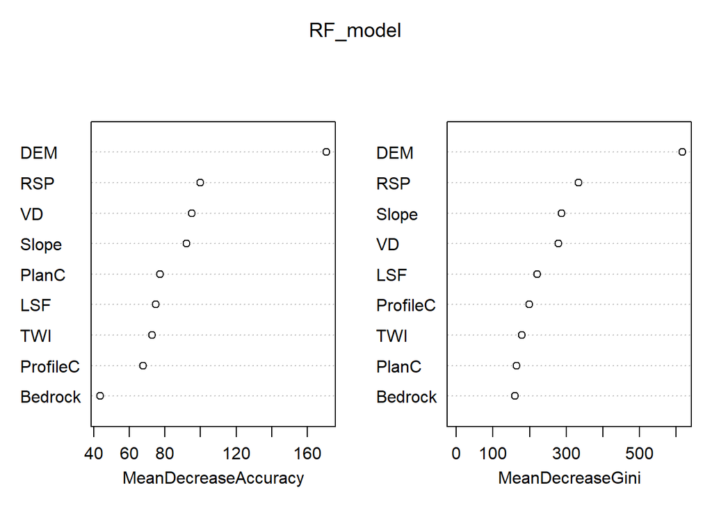

```r
sampleNum_dict[mn]<-nrow(sampData)

sampData$Bedrock<- droplevels(as.factor(sampData$Bedrock))
sampData$soilID<- droplevels(as.factor(sampData$soilID))

RF_model<-randomForest(soilID ~.,data = sampData,
                       importance = TRUE, proximity = FALSE,
                       ntree=1000,type="classification")

varImpPlot(RF_model)
```

```r
print(RF_model)
```

```
##
## Call:
##  randomForest(formula = soilID ~ ., data = sampData, importance = TRUE,      proximity = FALSE, ntree = 1000, type = "classification")
##                Type of random forest: classification
##                      Number of trees: 1000
## No. of variables tried at each split: 3
##
##         OOB estimate of  error rate: 24.55%
## Confusion matrix:
##      1  20 21  23   3 30 31 501 502 503   7 class.error
## 1   12   0  0   0   4  0  0   0   0   0   0   0.2500000
## 20   0 302 21   5   0  0  0   7   1  75  36   0.3243848
## 21   0  75 67   0   0  0  0   0   2  12   2   0.5759494
## 23   0   1  0 194   0 16  7   0   0  48  16   0.3120567
## 3    3   0  0   0 109  0  0  41   0   0   0   0.2875817
## 30   0   0  0  13   0 60  8   0   0   4   4   0.3258427
## 31   0   0  0  18   0  4 98   0   0   1   0   0.1900826
## 501  0   2  0   0  31  0  0 420   0   0  18   0.1082803
## 502  0   1  1   0   0  0  0   1  46   0   8   0.1929825
## 503  0  60  5  40   0  3  0   0   1 541  16   0.1876877
## 7    0  27  1   6   0  4  0  25   5  22 305   0.2278481
```

```r
map_RF <- predict(covStack, RF_model, paste(result_tif_folder,mn,".tif",sep=""),
                  format = "GTiff", datatype = "FLT4S", overwrite = TRUE)

rm("mn","shpPoint","sampData","RF_model","map_RF")
```

## ns5

RANst LSF ns5 15

```r
mn="All_pRANst_LSF_NS5_pen15"

shpPoint<-readOGR(paste(point_shp_folder,mn,".shp",sep = "")) ###
sampData <- extract(covStack, shpPoint, sp = TRUE,method = "simple")

sampData<-sampData@data

sampData<-sampData[sampData$soilID %in% soil_type,]

sampData<-na.omit(sampData)

print(dim(sampData))
```

```
## [1] 334  10
```

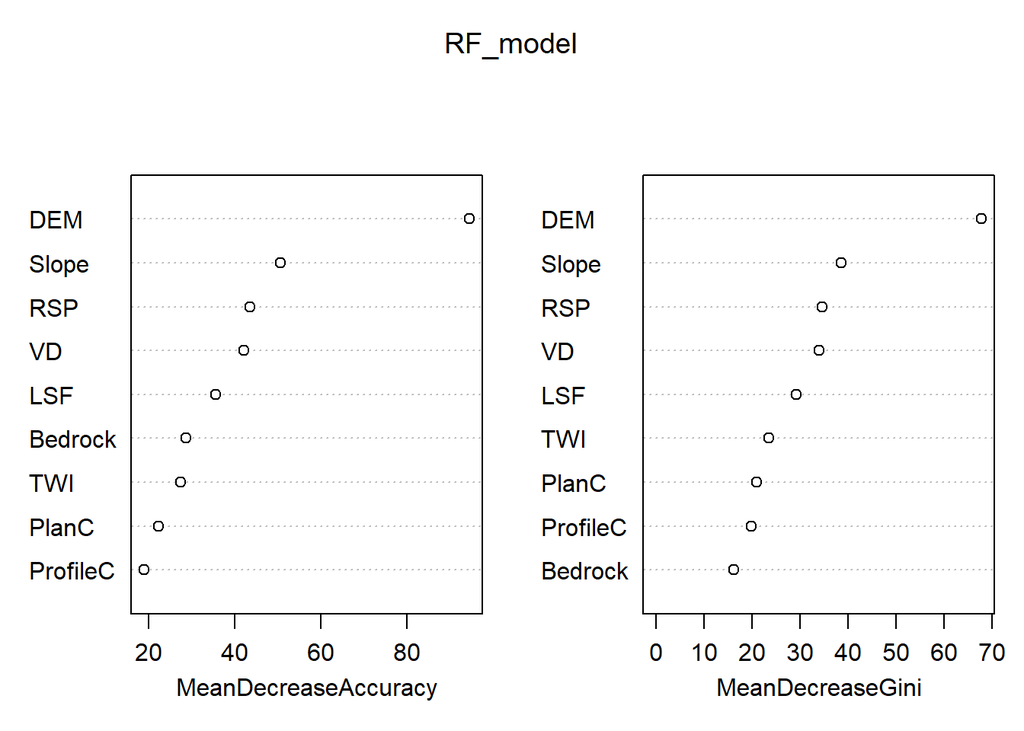

```r
sampleNum_dict[mn]<-nrow(sampData)

sampData$Bedrock<- droplevels(as.factor(sampData$Bedrock))
sampData$soilID<- droplevels(as.factor(sampData$soilID))

RF_model<-randomForest(soilID ~.,data = sampData,
                       importance = TRUE, proximity = FALSE,
                       ntree=1000,type="classification")

varImpPlot(RF_model)
```

```r
print(RF_model)
```

```
##
## Call:
##  randomForest(formula = soilID ~ ., data = sampData, importance = TRUE,      proximity = FALSE, ntree = 1000, type = "classification")
##                Type of random forest: classification
##                      Number of trees: 1000
## No. of variables tried at each split: 3
##
##         OOB estimate of  error rate: 34.73%
## Confusion matrix:
##     1 20 21 23 3 30 31 501 502 503  7 class.error
## 1   1  0  0  0 1  0  0   0   0   0  0   0.5000000
## 20  0 26  1  1 0  0  0   1   0   9  6   0.4090909
## 21  0  8 10  0 0  0  0   0   0   3  0   0.5238095
## 23  0  0  0 16 0  0  2   0   0   8  3   0.4482759
## 3   0  0  0  0 9  0  0  10   0   0  0   0.5263158
## 30  0  0  0  2 0  2  2   0   0   0  3   0.7777778
## 31  0  0  0  4 0  1  7   0   0   0  0   0.4166667
## 501 0  1  0  0 6  0  0  48   1   0  4   0.2000000
## 502 0  3  0  0 0  0  0   3   0   0  1   1.0000000
## 503 0  8  1  2 0  0  0   0   0  64  4   0.1898734
## 7   0  4  0  2 0  2  0   5   0   4 35   0.3269231
```

```r
map_RF <- predict(covStack, RF_model, paste(result_tif_folder,mn,".tif",sep=""),
                  format = "GTiff", datatype = "FLT4S", overwrite = TRUE)

rm("mn","shpPoint","sampData","RF_model","map_RF")
```

RANst LSF ns5 30

```r
mn="All_pRANst_LSF_NS5_pen30"

shpPoint<-readOGR(paste(point_shp_folder,mn,".shp",sep = "")) ###
sampData <- extract(covStack, shpPoint, sp = TRUE,method = "simple")

sampData<-sampData@data

sampData<-sampData[sampData$soilID %in% soil_type,]

sampData<-na.omit(sampData)

print(dim(sampData))
```

```
## [1] 629  10
```

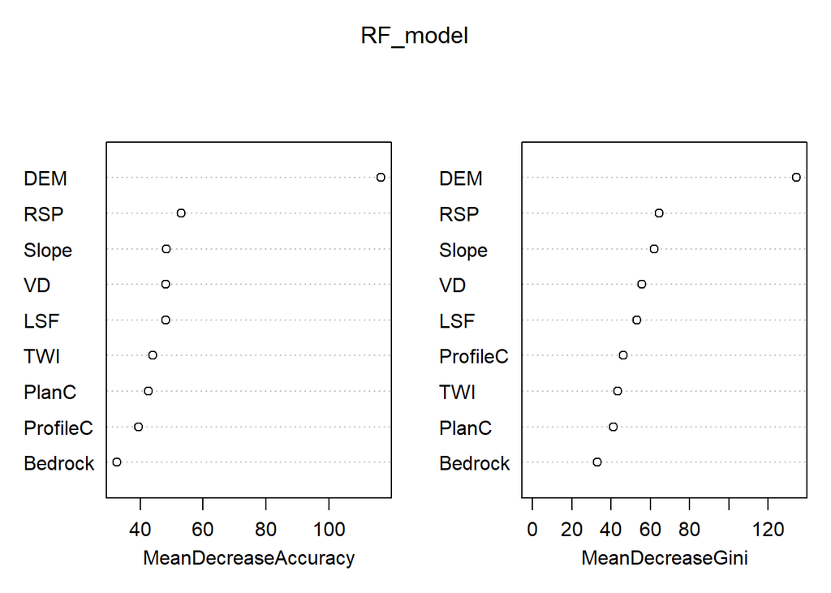

```r
sampleNum_dict[mn]<-nrow(sampData)

sampData$Bedrock<- droplevels(as.factor(sampData$Bedrock))
sampData$soilID<- droplevels(as.factor(sampData$soilID))

RF_model<-randomForest(soilID ~.,data = sampData,
                       importance = TRUE, proximity = FALSE,
                       ntree=1000,type="classification")

varImpPlot(RF_model)
```

```r
print(RF_model)
```

```
##
## Call:
##  randomForest(formula = soilID ~ ., data = sampData, importance = TRUE,      proximity = FALSE, ntree = 1000, type = "classification")
##                Type of random forest: classification
##                      Number of trees: 1000
## No. of variables tried at each split: 3
##
##         OOB estimate of  error rate: 31.64%
## Confusion matrix:
##     1 20 21 23  3 30 31 501 502 503  7 class.error
## 1   3  0  0  0  1  0  0   0   0   0  0   0.2500000
## 20  0 42 11  1  0  0  0   2   1  15  9   0.4814815
## 21  0 18 10  0  0  0  0   1   0   3  0   0.6875000
## 23  0  1  0 28  0  2  5   0   0  16  2   0.4814815
## 3   1  0  0  0 22  0  0  14   0   0  0   0.4054054
## 30  0  1  0  4  0  4  1   0   0   2  3   0.7333333
## 31  0  0  0  6  0  1 16   0   0   1  0   0.3333333
## 501 0  2  0  0  9  0  0 106   0   0  3   0.1166667
## 502 0  2  1  0  0  0  0   5   3   1  2   0.7857143
## 503 0  9  0 11  0  2  1   0   1 120  8   0.2105263
## 7   0  4  0  1  0  1  0   5   1   8 76   0.2083333
```

```r
map_RF <- predict(covStack, RF_model, paste(result_tif_folder,mn,".tif",sep=""),
                  format = "GTiff", datatype = "FLT4S", overwrite = TRUE)

rm("mn","shpPoint","sampData","RF_model","map_RF")
```

RANst LSF ns5 45

```r
mn="All_pRANst_LSF_NS5_pen45"

shpPoint<-readOGR(paste(point_shp_folder,mn,".shp",sep = "")) ###
sampData <- extract(covStack, shpPoint, sp = TRUE,method = "simple")

sampData<-sampData@data

sampData<-sampData[sampData$soilID %in% soil_type,]

sampData<-na.omit(sampData)

print(dim(sampData))
```

```
## [1] 927  10
```

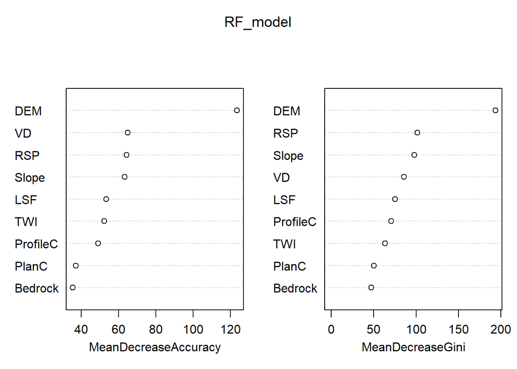

```r
sampleNum_dict[mn]<-nrow(sampData)

sampData$Bedrock<- droplevels(as.factor(sampData$Bedrock))
sampData$soilID<- droplevels(as.factor(sampData$soilID))

RF_model<-randomForest(soilID ~.,data = sampData,
                       importance = TRUE, proximity = FALSE,
                       ntree=1000,type="classification")

varImpPlot(RF_model)
```

```r
print(RF_model)
```

```
##
## Call:
##  randomForest(formula = soilID ~ ., data = sampData, importance = TRUE,      proximity = FALSE, ntree = 1000, type = "classification")
##                Type of random forest: classification
##                      Number of trees: 1000
## No. of variables tried at each split: 3
##
##         OOB estimate of  error rate: 28.48%
## Confusion matrix:
##     1 20 21 23  3 30 31 501 502 503  7 class.error
## 1   3  0  0  0  2  0  0   0   0   0  0   0.4000000
## 20  0 62 11  0  0  0  0   3   1  25 16   0.4745763
## 21  0 14 28  0  0  0  0   0   0   2  0   0.3636364
## 23  0  0  0 47  0  6  6   0   0  18  4   0.4197531
## 3   1  0  0  0 40  0  0  14   0   0  0   0.2727273
## 30  0  0  0  7  0 12  1   0   0   0  2   0.4545455
## 31  0  0  0 11  0  2 23   0   0   0  0   0.3611111
## 501 0  2  0  0 12  0  0 154   2   0  8   0.1348315
## 502 0  1  0  0  0  0  0   2  15   1  2   0.2857143
## 503 0 19  1 13  0  0  0   0   1 185  7   0.1814159
## 7   0 12  0  4  0  3  0  15   2  11 94   0.3333333
```

```r
map_RF <- predict(covStack, RF_model, paste(result_tif_folder,mn,".tif",sep=""),
                  format = "GTiff", datatype = "FLT4S", overwrite = TRUE)

rm("mn","shpPoint","sampData","RF_model","map_RF")
```

## ns7

RANst LSF ns7 15

```r
mn="All_pRANst_LSF_NS7_pen15"

shpPoint<-readOGR(paste(point_shp_folder,mn,".shp",sep = "")) ###
sampData <- extract(covStack, shpPoint, sp = TRUE,method = "simple")

sampData<-sampData@data

sampData<-sampData[sampData$soilID %in% soil_type,]

sampData<-na.omit(sampData)

print(dim(sampData))
```

```
## [1] 121  10
```

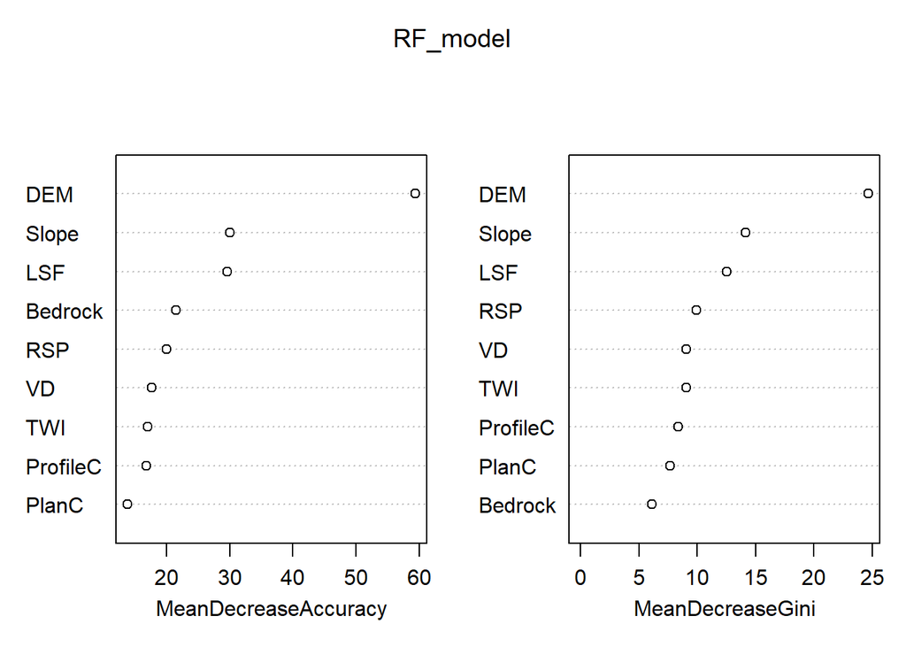

```r
sampleNum_dict[mn]<-nrow(sampData)

sampData$Bedrock<- droplevels(as.factor(sampData$Bedrock))
sampData$soilID<- droplevels(as.factor(sampData$soilID))

RF_model<-randomForest(soilID ~.,data = sampData,
                       importance = TRUE, proximity = FALSE,
                       ntree=1000,type="classification")

varImpPlot(RF_model)
```

```r
print(RF_model)
```

```
##
## Call:
##  randomForest(formula = soilID ~ ., data = sampData, importance = TRUE,      proximity = FALSE, ntree = 1000, type = "classification")
##                Type of random forest: classification
##                      Number of trees: 1000
## No. of variables tried at each split: 3
##
##         OOB estimate of  error rate: 34.71%
## Confusion matrix:
##     1 20 21 23 3 30 31 501 502 503  7 class.error
## 1   0  0  0  0 1  0  0   0   0   0  0   1.0000000
## 20  0 10  1  0 0  0  0   0   0   4  3   0.4444444
## 21  0  0  3  0 0  0  0   0   0   1  0   0.2500000
## 23  0  1  0  4 0  0  3   0   0   2  1   0.6363636
## 3   1  0  0  0 1  0  0   5   0   0  0   0.8571429
## 30  0  0  0  1 0  0  1   0   0   0  0   1.0000000
## 31  0  0  0  2 0  1  1   0   0   0  0   0.7500000
## 501 0  0  0  0 2  0  0  20   0   0  1   0.1304348
## 502 0  1  0  0 0  0  0   2   0   0  0   1.0000000
## 503 0  1  0  2 0  0  0   0   0  25  0   0.1071429
## 7   0  2  0  0 0  0  0   2   0   1 15   0.2500000
```

```r
map_RF <- predict(covStack, RF_model, paste(result_tif_folder,mn,".tif",sep=""),
                  format = "GTiff", datatype = "FLT4S", overwrite = TRUE)

rm("mn","shpPoint","sampData","RF_model","map_RF")
```

RANst LSF ns7 30

```r
mn="All_pRANst_LSF_NS7_pen30"

shpPoint<-readOGR(paste(point_shp_folder,mn,".shp",sep = "")) ###
sampData <- extract(covStack, shpPoint, sp = TRUE,method = "simple")

sampData<-sampData@data

sampData<-sampData[sampData$soilID %in% soil_type,]

sampData<-na.omit(sampData)

print(dim(sampData))
```

```
## [1] 217  10
```

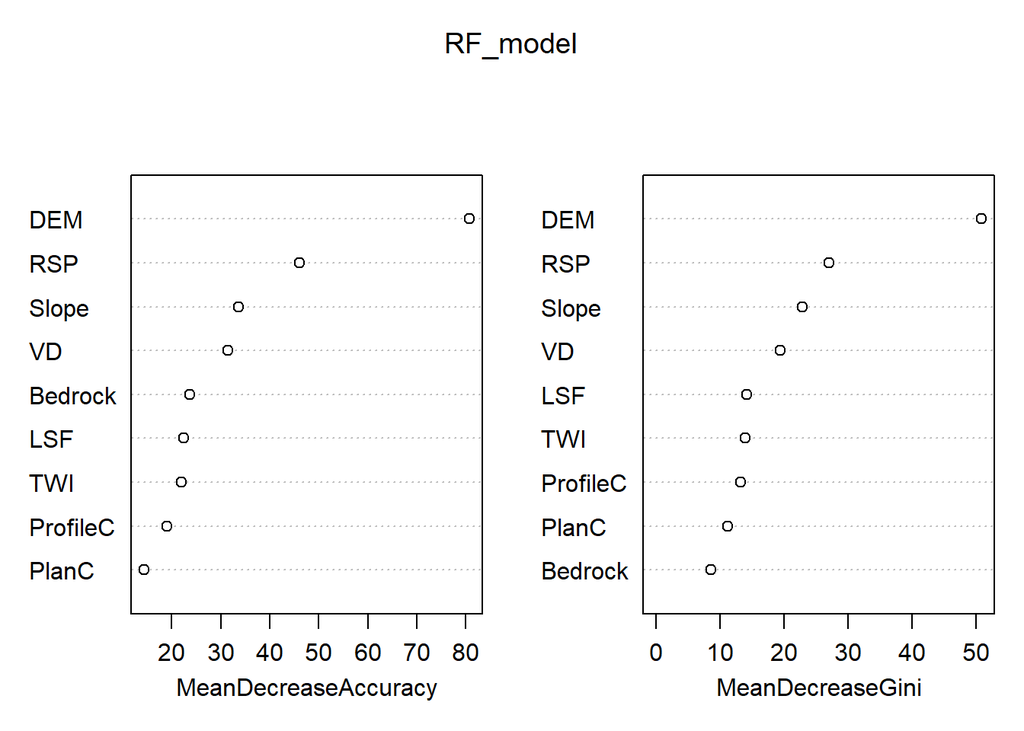

```r
sampleNum_dict[mn]<-nrow(sampData)

sampData$Bedrock<- droplevels(as.factor(sampData$Bedrock))
sampData$soilID<- droplevels(as.factor(sampData$soilID))

RF_model<-randomForest(soilID ~.,data = sampData,
                       importance = TRUE, proximity = FALSE,
                       ntree=1000,type="classification")

varImpPlot(RF_model)
```

```r
print(RF_model)
```

```
##
## Call:
##  randomForest(formula = soilID ~ ., data = sampData, importance = TRUE,      proximity = FALSE, ntree = 1000, type = "classification")
##                Type of random forest: classification
##                      Number of trees: 1000
## No. of variables tried at each split: 3
##
##         OOB estimate of  error rate: 29.03%
## Confusion matrix:
##     1 20 21 23  3 30 31 501 502 503  7 class.error
## 1   1  0  0  0  1  0  0   0   0   0  0  0.50000000
## 20  0 10  2  0  0  0  0   0   1  10  5  0.64285714
## 21  0  2  1  0  0  0  0   0   0   0  2  0.80000000
## 23  0  0  0 12  0  0  1   0   0   5  1  0.36842105
## 3   1  0  0  0 10  0  0   3   0   0  0  0.28571429
## 30  0  0  0  1  0  0  1   0   0   1  0  1.00000000
## 31  0  0  0  1  0  0  6   0   0   0  0  0.14285714
## 501 0  0  0  0  2  0  0  42   0   1  1  0.08695652
## 502 0  0  0  0  0  0  0   2   2   0  1  0.60000000
## 503 0  6  0  0  0  0  0   0   0  46  1  0.13207547
## 7   0  5  1  1  0  0  0   4   0   0 24  0.31428571
```

```r
map_RF <- predict(covStack, RF_model, paste(result_tif_folder,mn,".tif",sep=""),
                  format = "GTiff", datatype = "FLT4S", overwrite = TRUE)

rm("mn","shpPoint","sampData","RF_model","map_RF")
```

RANst LSF ns7 45

```r
mn="All_pRANst_LSF_NS7_pen45"

shpPoint<-readOGR(paste(point_shp_folder,mn,".shp",sep = "")) ###
sampData <- extract(covStack, shpPoint, sp = TRUE,method = "simple")

sampData<-sampData@data

sampData<-sampData[sampData$soilID %in% soil_type,]

sampData<-na.omit(sampData)

print(dim(sampData))
```

```
## [1] 309  10
```

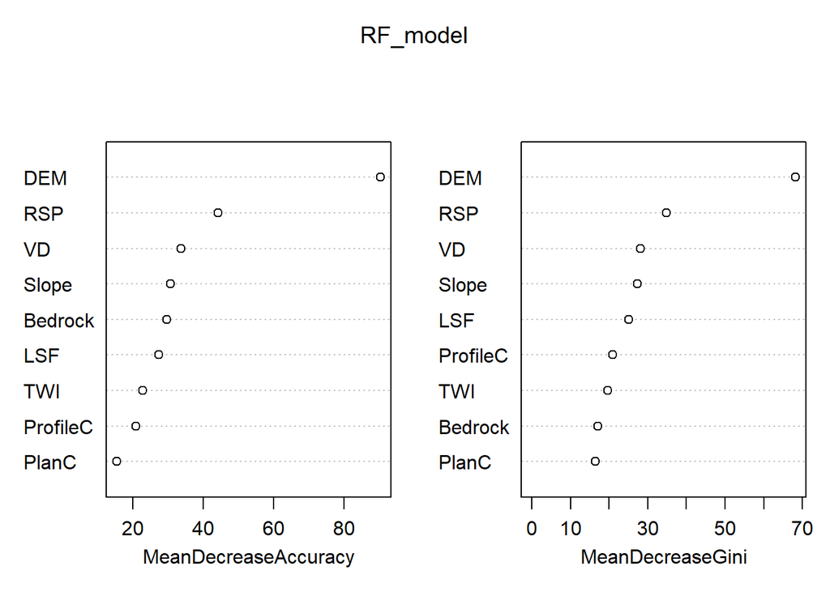

```r
sampleNum_dict[mn]<-nrow(sampData)

sampData$Bedrock<- droplevels(as.factor(sampData$Bedrock))
sampData$soilID<- droplevels(as.factor(sampData$soilID))

RF_model<-randomForest(soilID ~.,data = sampData,
                       importance = TRUE, proximity = FALSE,
                       ntree=1000,type="classification")

varImpPlot(RF_model)
```

```r
print(RF_model)
```

```
##
## Call:
##  randomForest(formula = soilID ~ ., data = sampData, importance = TRUE,      proximity = FALSE, ntree = 1000, type = "classification")
##                Type of random forest: classification
##                      Number of trees: 1000
## No. of variables tried at each split: 3
##
##         OOB estimate of  error rate: 35.28%
## Confusion matrix:
##     1 20 21 23  3 30 31 501 502 503  7 class.error
## 1   0  0  0  0  2  0  0   0   0   0  0   1.0000000
## 20  0 14  3  0  0  0  0   0   0  12  7   0.6111111
## 21  0  5  0  0  0  0  0   1   0   1  1   1.0000000
## 23  0  0  0 15  0  0  3   0   0   7  2   0.4444444
## 3   1  0  0  0 10  0  0   9   0   0  0   0.5000000
## 30  0  0  0  4  0  0  0   0   0   0  0   1.0000000
## 31  0  0  0  4  0  0  7   0   0   0  0   0.3636364
## 501 0  0  0  0  8  0  0  52   1   0  7   0.2352941
## 502 0  1  0  0  0  0  0   3   2   1  0   0.7142857
## 503 0  6  0  6  0  0  0   0   0  63  2   0.1818182
## 7   0  1  0  2  0  0  0   6   1   2 37   0.2448980
```

```r
map_RF <- predict(covStack, RF_model, paste(result_tif_folder,mn,".tif",sep=""),
                  format = "GTiff", datatype = "FLT4S", overwrite = TRUE)

rm("mn","shpPoint","sampData","RF_model","map_RF")
```

# VD -ok

## ns3

RANst VD ns3 15

```r
mn="All_pRANst_VD_NS3_pen15"

shpPoint<-readOGR(paste(point_shp_folder,mn,".shp",sep = "")) ###
sampData <- extract(covStack, shpPoint, sp = TRUE,method = "simple")

sampData<-sampData@data

sampData<-sampData[sampData$soilID %in% soil_type,]

sampData<-na.omit(sampData)

print(dim(sampData))
```

```
## [1] 1039   10
```

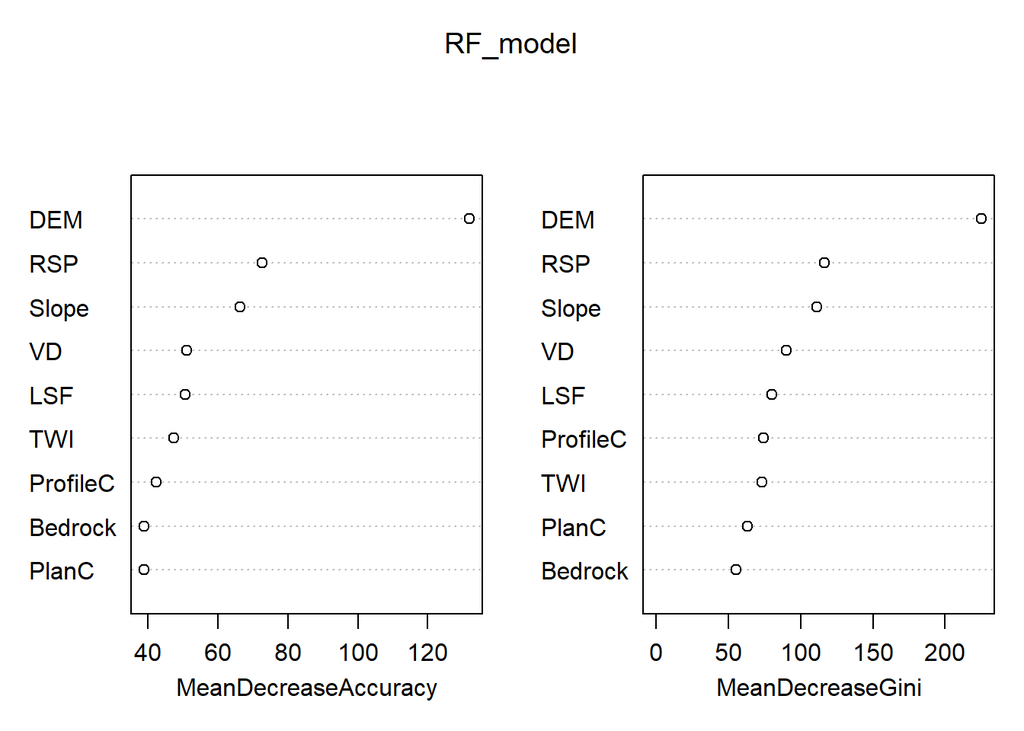

```r
sampleNum_dict[mn]<-nrow(sampData)

sampData$Bedrock<- droplevels(as.factor(sampData$Bedrock))
sampData$soilID<- droplevels(as.factor(sampData$soilID))

RF_model<-randomForest(soilID ~.,data = sampData,
                       importance = TRUE, proximity = FALSE,
                       ntree=1000,type="classification")

varImpPlot(RF_model)
```

```r
print(RF_model)
```

```
##
## Call:
##  randomForest(formula = soilID ~ ., data = sampData, importance = TRUE,      proximity = FALSE, ntree = 1000, type = "classification")
##                Type of random forest: classification
##                      Number of trees: 1000
## No. of variables tried at each split: 3
##
##         OOB estimate of  error rate: 30.61%
## Confusion matrix:
##     1  20 21 23  3 30 31 501 502 503  7 class.error
## 1   3   0  0  0  2  0  0   0   0   0  0   0.4000000
## 20  0 102 10  1  0  0  0   1   1  31 16   0.3703704
## 21  0  30 20  0  0  0  0   0   2   7  1   0.6666667
## 23  0   0  0 65  0  7  3   0   0  23  4   0.3627451
## 3   2   0  0  0 36  0  0  17   0   0  0   0.3454545
## 30  0   0  0  7  0 14  4   0   0   2  6   0.5757576
## 31  0   0  0  7  0  2 33   0   0   1  0   0.2325581
## 501 0   2  0  0 13  0  0 148   0   0  7   0.1294118
## 502 0   4  0  0  1  0  0   2  12   2  1   0.4545455
## 503 0  29  4 12  0  0  0   0   1 189  8   0.2222222
## 7   0  20  0  3  0  3  0   8   3   8 99   0.3125000
```

```r
map_RF <- predict(covStack, RF_model, paste(result_tif_folder,mn,".tif",sep=""),
                  format = "GTiff", datatype = "FLT4S", overwrite = TRUE)

rm("mn","shpPoint","sampData","RF_model","map_RF")
```

RANst VD ns3 30

```r
mn="All_pRANst_VD_NS3_pen30"

shpPoint<-readOGR(paste(point_shp_folder,mn,".shp",sep = "")) ###
sampData <- extract(covStack, shpPoint, sp = TRUE,method = "simple")

sampData<-sampData@data

sampData<-sampData[sampData$soilID %in% soil_type,]

sampData<-na.omit(sampData)

print(dim(sampData))
```

```
## [1] 2043   10
```

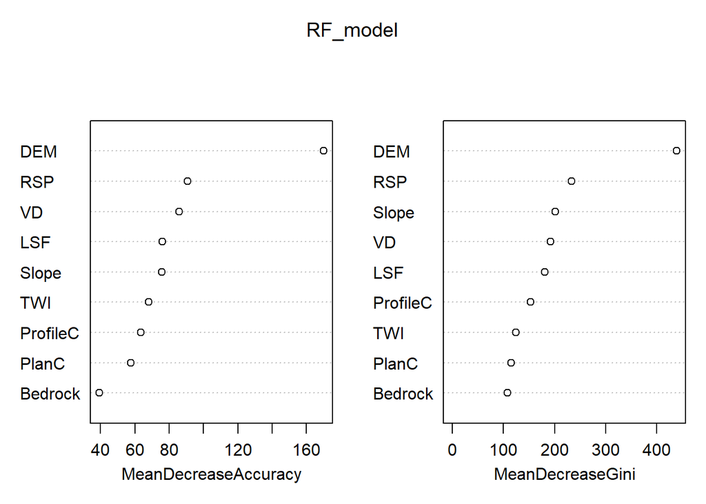

```r
sampleNum_dict[mn]<-nrow(sampData)

sampData$Bedrock<- droplevels(as.factor(sampData$Bedrock))
sampData$soilID<- droplevels(as.factor(sampData$soilID))

RF_model<-randomForest(soilID ~.,data = sampData,
                       importance = TRUE, proximity = FALSE,
                       ntree=1000,type="classification")

varImpPlot(RF_model)
```

```r
print(RF_model)
```

```
##
## Call:
##  randomForest(formula = soilID ~ ., data = sampData, importance = TRUE,      proximity = FALSE, ntree = 1000, type = "classification")
##                Type of random forest: classification
##                      Number of trees: 1000
## No. of variables tried at each split: 3
##
##         OOB estimate of  error rate: 26.09%
## Confusion matrix:
##     1  20 21  23  3 30 31 501 502 503   7 class.error
## 1   9   0  0   0  3  0  0   0   0   0   0   0.2500000
## 20  0 191 26   3  0  0  0   6   3  61  28   0.3993711
## 21  0  55 46   0  0  0  0   2   2   7   0   0.5892857
## 23  0   3  0 140  0 14  5   0   0  25   8   0.2820513
## 3   4   0  0   0 74  0  0  32   0   0   0   0.3272727
## 30  0   0  0  13  0 36  6   0   0   2   5   0.4193548
## 31  0   0  0  11  0  4 68   0   0   2   0   0.2000000
## 501 0   3  0   0 21  0  0 306   0   0  10   0.1000000
## 502 0   7  0   0  0  0  0   1  31   1   2   0.2619048
## 503 0  49  5  26  0  1  0   0   1 387  15   0.2004132
## 7   0  14  1   1  0  6  0  19   2  18 222   0.2155477
```

```r
map_RF <- predict(covStack, RF_model, paste(result_tif_folder,mn,".tif",sep=""),
                  format = "GTiff", datatype = "FLT4S", overwrite = TRUE)

rm("mn","shpPoint","sampData","RF_model","map_RF")
```

RANst VD ns3 45

```r
mn="All_pRANst_VD_NS3_pen45"

shpPoint<-readOGR(paste(point_shp_folder,mn,".shp",sep = "")) ###
sampData <- extract(covStack, shpPoint, sp = TRUE,method = "simple")

sampData<-sampData@data

sampData<-sampData[sampData$soilID %in% soil_type,]

sampData<-na.omit(sampData)

print(dim(sampData))
```

```
## [1] 3037   10
```

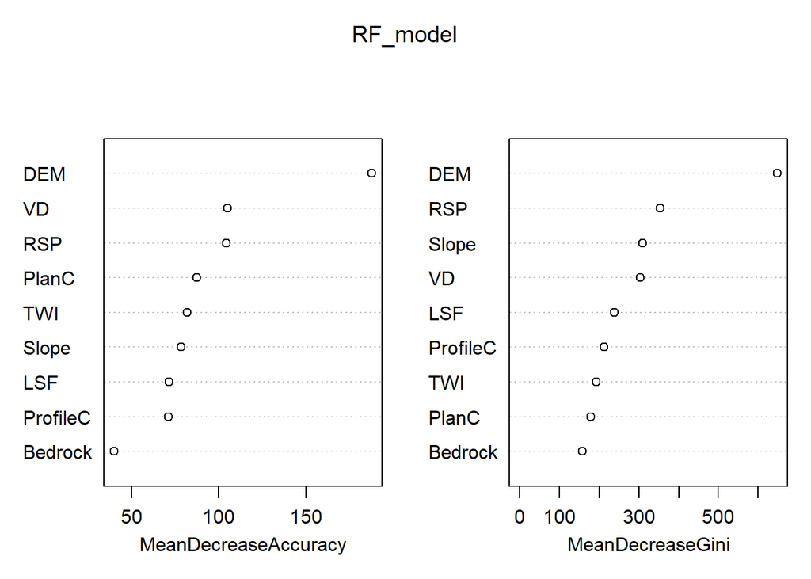

```r
sampleNum_dict[mn]<-nrow(sampData)

sampData$Bedrock<- droplevels(as.factor(sampData$Bedrock))
sampData$soilID<- droplevels(as.factor(sampData$soilID))

RF_model<-randomForest(soilID ~.,data = sampData,
                       importance = TRUE, proximity = FALSE,
                       ntree=1000,type="classification")

varImpPlot(RF_model)
```

```r
print(RF_model)
```

```
##
## Call:
##  randomForest(formula = soilID ~ ., data = sampData, importance = TRUE,      proximity = FALSE, ntree = 1000, type = "classification")
##                Type of random forest: classification
##                      Number of trees: 1000
## No. of variables tried at each split: 3
##
##         OOB estimate of  error rate: 23.51%
## Confusion matrix:
##      1  20 21  23   3 30  31 501 502 503   7 class.error
## 1   14   0  0   0   3  0   0   0   0   0   0   0.1764706
## 20   0 323 28   4   0  0   0  11   2  66  36   0.3127660
## 21   0  72 79   0   0  0   0   1   2  11   1   0.5240964
## 23   0   1  0 206   0 15  14   0   0  44   9   0.2871972
## 3    4   0  0   0 122  0   0  39   0   0   0   0.2606061
## 30   0   0  0  18   0 55   5   0   0   4   8   0.3888889
## 31   0   0  0  20   0  5 102   0   0   0   0   0.1968504
## 501  0   8  1   0  36  0   0 446   0   0  19   0.1254902
## 502  0   5  2   0   0  0   0   1  41   5   7   0.3278689
## 503  0  64  1  26   0  5   1   0   2 609  15   0.1576763
## 7    0  32  1   3   0  7   0  29   4  17 326   0.2219570
```

```r
map_RF <- predict(covStack, RF_model, paste(result_tif_folder,mn,".tif",sep=""),
                  format = "GTiff", datatype = "FLT4S", overwrite = TRUE)

rm("mn","shpPoint","sampData","RF_model","map_RF")
```

## ns5

RANst VD ns5 15

```r
mn="All_pRANst_VD_NS5_pen15"

shpPoint<-readOGR(paste(point_shp_folder,mn,".shp",sep = "")) ###
sampData <- extract(covStack, shpPoint, sp = TRUE,method = "simple")

sampData<-sampData@data

sampData<-sampData[sampData$soilID %in% soil_type,]

sampData<-na.omit(sampData)

print(dim(sampData))
```

```
## [1] 355  10
```

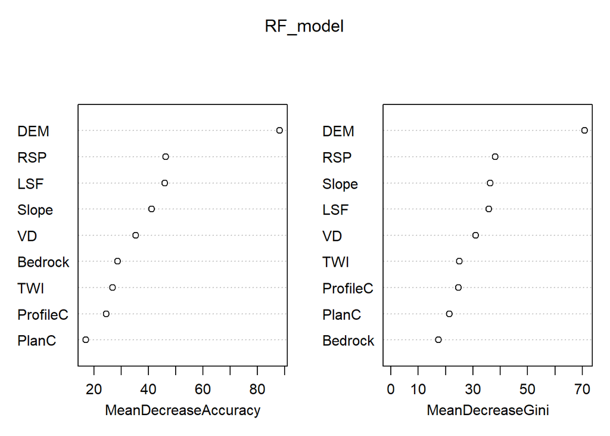

```r
sampleNum_dict[mn]<-nrow(sampData)

sampData$Bedrock<- droplevels(as.factor(sampData$Bedrock))
sampData$soilID<- droplevels(as.factor(sampData$soilID))

RF_model<-randomForest(soilID ~.,data = sampData,
                       importance = TRUE, proximity = FALSE,
                       ntree=1000,type="classification")

varImpPlot(RF_model)
```

```r
print(RF_model)
```

```
##
## Call:
##  randomForest(formula = soilID ~ ., data = sampData, importance = TRUE,      proximity = FALSE, ntree = 1000, type = "classification")
##                Type of random forest: classification
##                      Number of trees: 1000
## No. of variables tried at each split: 3
##
##         OOB estimate of  error rate: 37.75%
## Confusion matrix:
##     1 20 21 23  3 30 31 501 502 503  7 class.error
## 1   2  0  0  0  0  0  0   0   0   0  0   0.0000000
## 20  0 21  7  1  0  0  0   0   0  13  6   0.5625000
## 21  0 13  4  0  0  0  0   1   0   3  0   0.8095238
## 23  0  0  0 17  0  2  1   0   0   8  2   0.4333333
## 3   1  0  0  0 10  0  0   9   0   0  0   0.5000000
## 30  0  0  0  3  0  0  5   0   0   0  0   1.0000000
## 31  0  0  0  3  0  1  9   0   0   0  0   0.3076923
## 501 0  0  0  0  8  0  0  52   1   0  4   0.2000000
## 502 0  3  0  0  0  0  0   4   1   0  0   0.8750000
## 503 0 10  1  5  0  0  0   0   0  69  2   0.2068966
## 7   0  3  0  1  0  0  0   6   0   7 36   0.3207547
```

```r
map_RF <- predict(covStack, RF_model, paste(result_tif_folder,mn,".tif",sep=""),
                  format = "GTiff", datatype = "FLT4S", overwrite = TRUE)

rm("mn","shpPoint","sampData","RF_model","map_RF")
```

RANst VD ns5 30

```r
mn="All_pRANst_VD_NS5_pen30"

shpPoint<-readOGR(paste(point_shp_folder,mn,".shp",sep = "")) ###
sampData <- extract(covStack, shpPoint, sp = TRUE,method = "simple")

sampData<-sampData@data

sampData<-sampData[sampData$soilID %in% soil_type,]

sampData<-na.omit(sampData)

print(dim(sampData))
```

```
## [1] 673  10
```

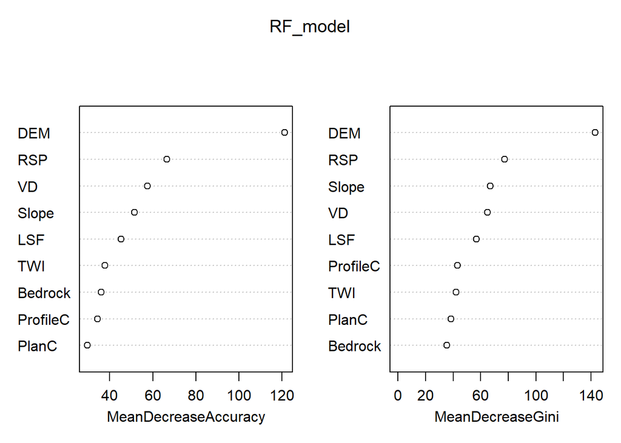

```r
sampleNum_dict[mn]<-nrow(sampData)

sampData$Bedrock<- droplevels(as.factor(sampData$Bedrock))
sampData$soilID<- droplevels(as.factor(sampData$soilID))

RF_model<-randomForest(soilID ~.,data = sampData,
                       importance = TRUE, proximity = FALSE,
                       ntree=1000,type="classification")

varImpPlot(RF_model)
```

```r
print(RF_model)
```

```
##
## Call:
##  randomForest(formula = soilID ~ ., data = sampData, importance = TRUE,      proximity = FALSE, ntree = 1000, type = "classification")
##                Type of random forest: classification
##                      Number of trees: 1000
## No. of variables tried at each split: 3
##
##         OOB estimate of  error rate: 33.73%
## Confusion matrix:
##     1 20 21 23  3 30 31 501 502 503  7 class.error
## 1   0  0  0  0  2  0  0   0   0   0  0   1.0000000
## 20  0 35 10  0  0  0  0   5   2  21 15   0.6022727
## 21  0 19  7  0  0  0  0   0   0   6  0   0.7812500
## 23  0  0  0 28  0  3  5   0   0  18  1   0.4909091
## 3   1  0  0  0 22  0  0  16   0   0  0   0.4358974
## 30  0  0  0  7  0  3  3   0   0   1  1   0.8000000
## 31  0  0  0  8  0  0 17   0   0   1  0   0.3461538
## 501 0  2  0  0  8  0  0 113   0   0  7   0.1307692
## 502 0  3  0  0  0  0  0   2   7   1  2   0.5333333
## 503 0 11  1 11  0  1  0   0   1 137  6   0.1845238
## 7   0  8  0  1  0  0  0   9   1   7 77   0.2524272
```

```r
map_RF <- predict(covStack, RF_model, paste(result_tif_folder,mn,".tif",sep=""),
                  format = "GTiff", datatype = "FLT4S", overwrite = TRUE)

rm("mn","shpPoint","sampData","RF_model","map_RF")
```

RANst VD ns5 45

```r
mn="All_pRANst_VD_NS5_pen45"

shpPoint<-readOGR(paste(point_shp_folder,mn,".shp",sep = "")) ###
sampData <- extract(covStack, shpPoint, sp = TRUE,method = "simple")

sampData<-sampData@data

sampData<-sampData[sampData$soilID %in% soil_type,]

sampData<-na.omit(sampData)

print(dim(sampData))
```

```
## [1] 993  10
```

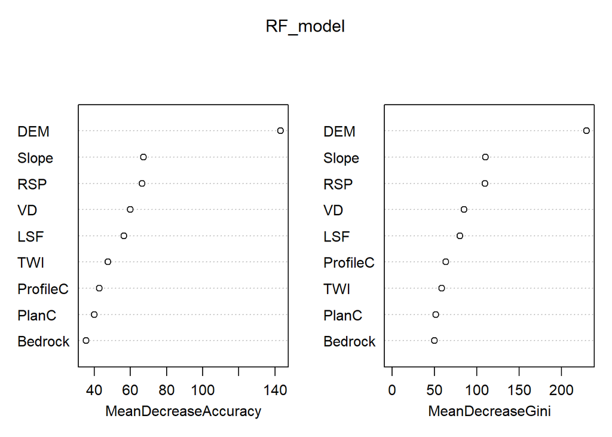

```r
sampleNum_dict[mn]<-nrow(sampData)

sampData$Bedrock<- droplevels(as.factor(sampData$Bedrock))
sampData$soilID<- droplevels(as.factor(sampData$soilID))

RF_model<-randomForest(soilID ~.,data = sampData,
                       importance = TRUE, proximity = FALSE,
                       ntree=1000,type="classification")

varImpPlot(RF_model)
```

```r
print(RF_model)
```

```
##
## Call:
##  randomForest(formula = soilID ~ ., data = sampData, importance = TRUE,      proximity = FALSE, ntree = 1000, type = "classification")
##                Type of random forest: classification
##                      Number of trees: 1000
## No. of variables tried at each split: 3
##
##         OOB estimate of  error rate: 24.57%
## Confusion matrix:
##     1 20 21 23  3 30 31 501 502 503   7 class.error
## 1   2  0  0  0  3  0  0   0   0   0   0   0.6000000
## 20  0 78  6  0  0  0  0   2   3  24  18   0.4045802
## 21  0 17 19  0  0  0  0   0   4   3   1   0.5681818
## 23  0  0  0 54  0  5  3   0   0  17   2   0.3333333
## 3   2  0  0  0 38  0  0  18   0   0   0   0.3448276
## 30  0  1  0  5  0  7  4   0   0   2   1   0.6500000
## 31  0  0  0  6  0  2 30   0   0   1   0   0.2307692
## 501 0  0  0  0  8  0  0 173   2   0  11   0.1082474
## 502 0  2  0  0  0  0  0   2  15   0   3   0.3181818
## 503 0 17  2 10  0  1  0   0   1 212   7   0.1520000
## 7   0  8  0  0  0  1  0  12   0   7 121   0.1879195
```

```r
map_RF <- predict(covStack, RF_model, paste(result_tif_folder,mn,".tif",sep=""),
                  format = "GTiff", datatype = "FLT4S", overwrite = TRUE)

rm("mn","shpPoint","sampData","RF_model","map_RF")
```

## ns7

RANst VD ns7 15

```r
mn="All_pRANst_VD_NS7_pen15"

shpPoint<-readOGR(paste(point_shp_folder,mn,".shp",sep = "")) ###
sampData <- extract(covStack, shpPoint, sp = TRUE,method = "simple")

sampData<-sampData@data

sampData<-sampData[sampData$soilID %in% soil_type,]

sampData<-na.omit(sampData)

print(dim(sampData))
```

```
## [1] 257  10
```

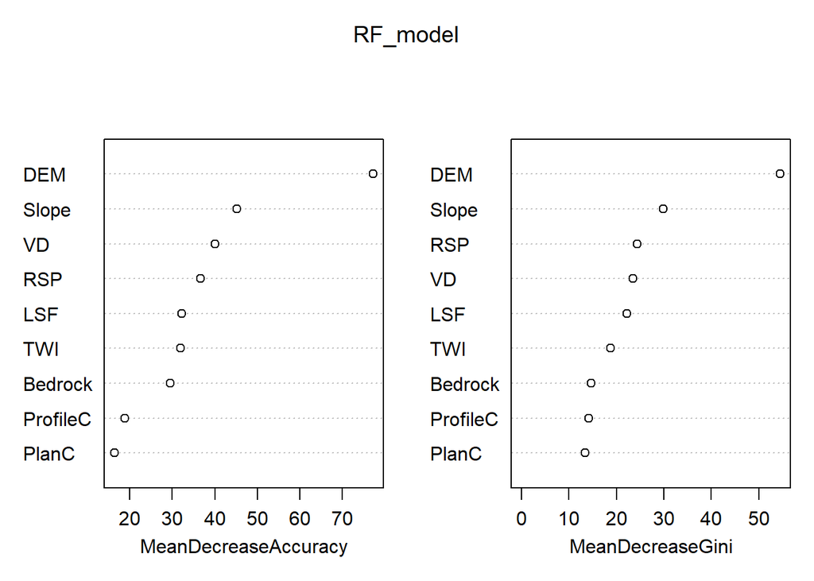

```r
sampleNum_dict[mn]<-nrow(sampData)

sampData$Bedrock<- droplevels(as.factor(sampData$Bedrock))
sampData$soilID<- droplevels(as.factor(sampData$soilID))

RF_model<-randomForest(soilID ~.,data = sampData,
                       importance = TRUE, proximity = FALSE,
                       ntree=1000,type="classification")

varImpPlot(RF_model)
```

```r
print(RF_model)
```

```
##
## Call:
##  randomForest(formula = soilID ~ ., data = sampData, importance = TRUE,      proximity = FALSE, ntree = 1000, type = "classification")
##                Type of random forest: classification
##                      Number of trees: 1000
## No. of variables tried at each split: 3
##
##         OOB estimate of  error rate: 31.52%
## Confusion matrix:
##     1 20 21 23 3 30 31 501 502 503  7 class.error
## 1   0  0  0  0 2  0  0   0   0   0  0   1.0000000
## 20  0 24  2  0 0  0  0   0   1   5  3   0.3142857
## 21  0  7  1  0 0  0  0   0   0   0  0   0.8750000
## 23  0  0  0  9 0  1  2   0   0   7  3   0.5909091
## 3   1  0  0  0 9  0  0   4   0   0  0   0.3571429
## 30  0  0  0  3 0  0  1   0   0   0  0   1.0000000
## 31  0  0  0  3 0  0  5   0   0   0  0   0.3750000
## 501 0  0  0  0 4  0  0  46   0   1  1   0.1153846
## 502 0  0  0  0 0  0  0   3   2   0  2   0.7142857
## 503 0  4  1  4 0  0  0   0   0  49  4   0.2096774
## 7   0  2  0  2 0  0  0   4   1   3 31   0.2790698
```

```r
map_RF <- predict(covStack, RF_model, paste(result_tif_folder,mn,".tif",sep=""),
                  format = "GTiff", datatype = "FLT4S", overwrite = TRUE)

rm("mn","shpPoint","sampData","RF_model","map_RF")
```

RANst VD ns7 30

```r
mn="All_pRANst_VD_NS7_pen30"

shpPoint<-readOGR(paste(point_shp_folder,mn,".shp",sep = "")) ###
sampData <- extract(covStack, shpPoint, sp = TRUE,method = "simple")

sampData<-sampData@data

sampData<-sampData[sampData$soilID %in% soil_type,]

sampData<-na.omit(sampData)

print(dim(sampData))
```

```
## [1] 227  10
```

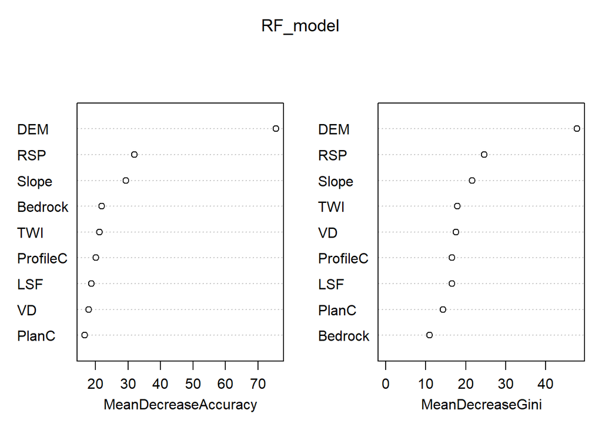

```r
sampleNum_dict[mn]<-nrow(sampData)

sampData$Bedrock<- droplevels(as.factor(sampData$Bedrock))
sampData$soilID<- droplevels(as.factor(sampData$soilID))

RF_model<-randomForest(soilID ~.,data = sampData,
                       importance = TRUE, proximity = FALSE,
                       ntree=1000,type="classification")

varImpPlot(RF_model)
```

```r
print(RF_model)
```

```
##
## Call:
##  randomForest(formula = soilID ~ ., data = sampData, importance = TRUE,      proximity = FALSE, ntree = 1000, type = "classification")
##                Type of random forest: classification
##                      Number of trees: 1000
## No. of variables tried at each split: 3
##
##         OOB estimate of  error rate: 38.77%
## Confusion matrix:
##     1 20 21 23 3 30 31 501 502 503  7 class.error
## 1   0  0  0  0 1  0  0   0   0   0  0   1.0000000
## 20  0 12  1  0 0  0  0   1   0  10  3   0.5555556
## 21  0  2  0  0 0  0  0   0   0   3  0   1.0000000
## 23  0  0  0  9 0  0  3   0   0   6  1   0.5263158
## 3   0  0  0  0 7  0  0   6   0   0  0   0.4615385
## 30  0  0  0  0 0  0  1   0   0   0  2   1.0000000
## 31  0  0  0  1 0  0  6   0   0   0  0   0.1428571
## 501 0  1  0  0 6  0  0  37   1   0  6   0.2745098
## 502 0  0  0  0 0  0  0   3   2   0  1   0.6666667
## 503 0  6  2  4 0  0  0   0   0  41  4   0.2807018
## 7   0  1  0  1 0  2  0   5   0   4 25   0.3421053
```

```r
map_RF <- predict(covStack, RF_model, paste(result_tif_folder,mn,".tif",sep=""),
                  format = "GTiff", datatype = "FLT4S", overwrite = TRUE)

rm("mn","shpPoint","sampData","RF_model","map_RF")
```

RANst VD ns7 45

```r
mn="All_pRANst_VD_NS7_pen45"

shpPoint<-readOGR(paste(point_shp_folder,mn,".shp",sep = "")) ###
sampData <- extract(covStack, shpPoint, sp = TRUE,method = "simple")

sampData<-sampData@data

sampData<-sampData[sampData$soilID %in% soil_type,]

sampData<-na.omit(sampData)

print(dim(sampData))
```

```
## [1] 323  10
```

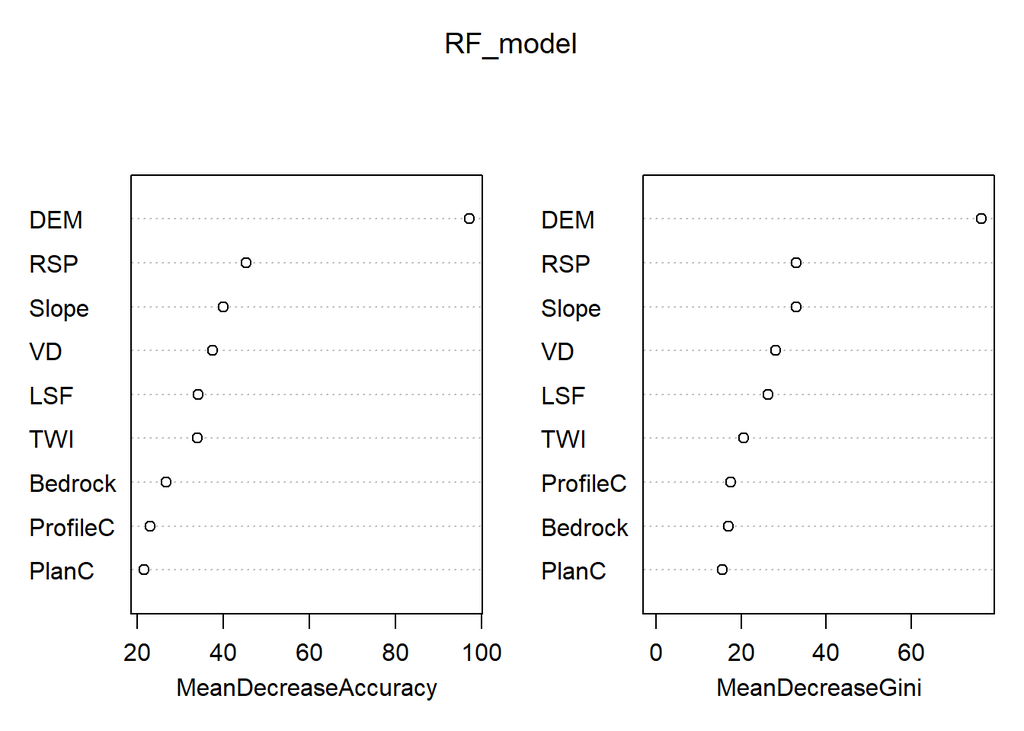

```r
sampleNum_dict[mn]<-nrow(sampData)

sampData$Bedrock<- droplevels(as.factor(sampData$Bedrock))
sampData$soilID<- droplevels(as.factor(sampData$soilID))

RF_model<-randomForest(soilID ~.,data = sampData,
                       importance = TRUE, proximity = FALSE,
                       ntree=1000,type="classification")

varImpPlot(RF_model)
```

```r
print(RF_model)
```

```
##
## Call:
##  randomForest(formula = soilID ~ ., data = sampData, importance = TRUE,      proximity = FALSE, ntree = 1000, type = "classification")
##                Type of random forest: classification
##                      Number of trees: 1000
## No. of variables tried at each split: 3
##
##         OOB estimate of  error rate: 29.72%
## Confusion matrix:
##     1 20 21 23  3 30 31 501 502 503  7 class.error
## 1   0  0  0  0  1  0  0   0   0   0  0   1.0000000
## 20  0 16  4  0  0  0  0   0   0   9  6   0.5428571
## 21  0  6  1  0  0  0  0   0   1   0  0   0.8750000
## 23  0  0  0 18  0  1  1   0   0   8  0   0.3571429
## 3   0  0  0  0 13  0  0   7   0   0  0   0.3500000
## 30  0  0  0  0  0  2  0   0   0   1  1   0.5000000
## 31  0  0  0  3  0  0  7   0   0   0  0   0.3000000
## 501 0  0  0  0  3  0  0  67   1   0  4   0.1066667
## 502 0  0  0  0  0  0  0   5   0   0  2   1.0000000
## 503 0  9  0  4  0  0  0   0   0  61  7   0.2469136
## 7   0  1  0  0  0  0  0   7   0   4 42   0.2222222
```

```r
map_RF <- predict(covStack, RF_model, paste(result_tif_folder,mn,".tif",sep=""),
                  format = "GTiff", datatype = "FLT4S", overwrite = TRUE)

rm("mn","shpPoint","sampData","RF_model","map_RF")
```

# RSP -ok

## ns3

RANst RSP ns3 15

```r
mn="All_pRANst_RSP_NS3_pen15"

shpPoint<-readOGR(paste(point_shp_folder,mn,".shp",sep = "")) ###
sampData <- extract(covStack, shpPoint, sp = TRUE,method = "simple")

sampData<-sampData@data

sampData<-sampData[sampData$soilID %in% soil_type,]

sampData<-na.omit(sampData)

print(dim(sampData))
```

```
## [1] 1043   10
```

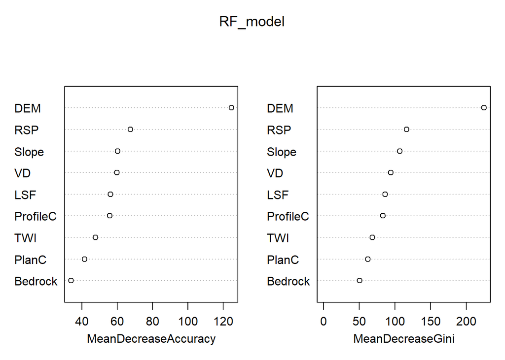

```r
sampleNum_dict[mn]<-nrow(sampData)

sampData$Bedrock<- droplevels(as.factor(sampData$Bedrock))
sampData$soilID<- droplevels(as.factor(sampData$soilID))

RF_model<-randomForest(soilID ~.,data = sampData,
                       importance = TRUE, proximity = FALSE,
                       ntree=1000,type="classification")

varImpPlot(RF_model)
```

```r
print(RF_model)
```

```
##
## Call:
##  randomForest(formula = soilID ~ ., data = sampData, importance = TRUE,      proximity = FALSE, ntree = 1000, type = "classification")
##                Type of random forest: classification
##                      Number of trees: 1000
## No. of variables tried at each split: 3
##
##         OOB estimate of  error rate: 29.72%
## Confusion matrix:
##     1 20 21 23  3 30 31 501 502 503   7 class.error
## 1   4  0  0  0  2  0  0   0   0   0   0   0.3333333
## 20  0 96 10  1  0  0  0   2   0  36  20   0.4181818
## 21  0 29 26  0  0  0  0   0   3   3   1   0.5806452
## 23  0  0  0 62  0  8  5   0   0  18   9   0.3921569
## 3   2  0  0  0 36  0  0  17   0   0   0   0.3454545
## 30  0  0  0 10  0 20  0   0   0   1   2   0.3939394
## 31  0  0  0 12  0  3 25   0   0   0   0   0.3750000
## 501 0  2  0  0 12  0  0 152   0   0   4   0.1058824
## 502 0  2  1  0  0  0  0   2  14   0   3   0.3636364
## 503 0 25  4 16  0  1  0   0   0 194   4   0.2049180
## 7   0 14  0  4  0  3  0  10   1   8 104   0.2777778
```

```r
map_RF <- predict(covStack, RF_model, paste(result_tif_folder,mn,".tif",sep=""),
                  format = "GTiff", datatype = "FLT4S", overwrite = TRUE)

rm("mn","shpPoint","sampData","RF_model","map_RF")
```

RANst RSP ns3 30

```r
mn="All_pRANst_RSP_NS3_pen30"

shpPoint<-readOGR(paste(point_shp_folder,mn,".shp",sep = "")) ###
sampData <- extract(covStack, shpPoint, sp = TRUE,method = "simple")

sampData<-sampData@data

sampData<-sampData[sampData$soilID %in% soil_type,]

sampData<-na.omit(sampData)

print(dim(sampData))
```

```
## [1] 2034   10
```

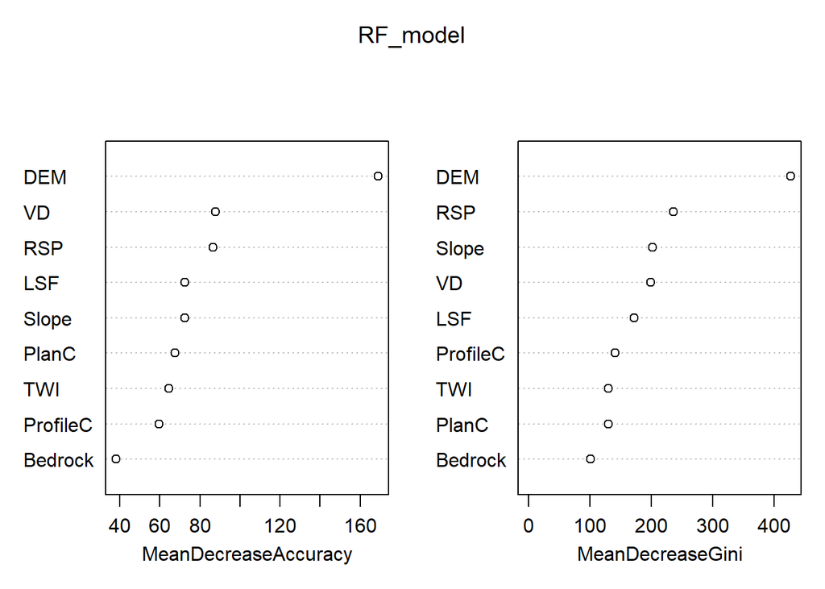

```r
sampleNum_dict[mn]<-nrow(sampData)

sampData$Bedrock<- droplevels(as.factor(sampData$Bedrock))
sampData$soilID<- droplevels(as.factor(sampData$soilID))

RF_model<-randomForest(soilID ~.,data = sampData,
                       importance = TRUE, proximity = FALSE,
                       ntree=1000,type="classification")

varImpPlot(RF_model)
```

```r
print(RF_model)
```

```
##
## Call:
##  randomForest(formula = soilID ~ ., data = sampData, importance = TRUE,      proximity = FALSE, ntree = 1000, type = "classification")
##                Type of random forest: classification
##                      Number of trees: 1000
## No. of variables tried at each split: 3
##
##         OOB estimate of  error rate: 26.3%
## Confusion matrix:
##     1  20 21  23  3 30 31 501 502 503   7 class.error
## 1   8   0  0   0  3  0  0   0   0   0   0   0.2727273
## 20  0 199 22   1  0  0  0   6   4  56  30   0.3742138
## 21  0  47 55   0  0  0  0   1   0  10   1   0.5175439
## 23  0   2  0 129  0  6  6   0   0  41  11   0.3384615
## 3   2   0  0   0 73  0  0  35   0   0   0   0.3363636
## 30  0   0  0  11  0 41  4   0   0   3   3   0.3387097
## 31  0   0  0  11  0  8 59   0   0   2   0   0.2625000
## 501 0   0  0   0 23  0  0 302   0   0  15   0.1117647
## 502 0   5  0   0  0  0  0   1  34   0   1   0.1707317
## 503 0  47  5  25  0  3  2   0   0 392   8   0.1867220
## 7   0  26  0   7  0  3  0  13   0  25 207   0.2633452
```

```r
map_RF <- predict(covStack, RF_model, paste(result_tif_folder,mn,".tif",sep=""),
                  format = "GTiff", datatype = "FLT4S", overwrite = TRUE)

rm("mn","shpPoint","sampData","RF_model","map_RF")
```

RANst RSP ns3 45

```r
mn="All_pRANst_RSP_NS3_pen45"

shpPoint<-readOGR(paste(point_shp_folder,mn,".shp",sep = "")) ###
sampData <- extract(covStack, shpPoint, sp = TRUE,method = "simple")

sampData<-sampData@data

sampData<-sampData[sampData$soilID %in% soil_type,]

sampData<-na.omit(sampData)

print(dim(sampData))
```

```
## [1] 3034   10
```

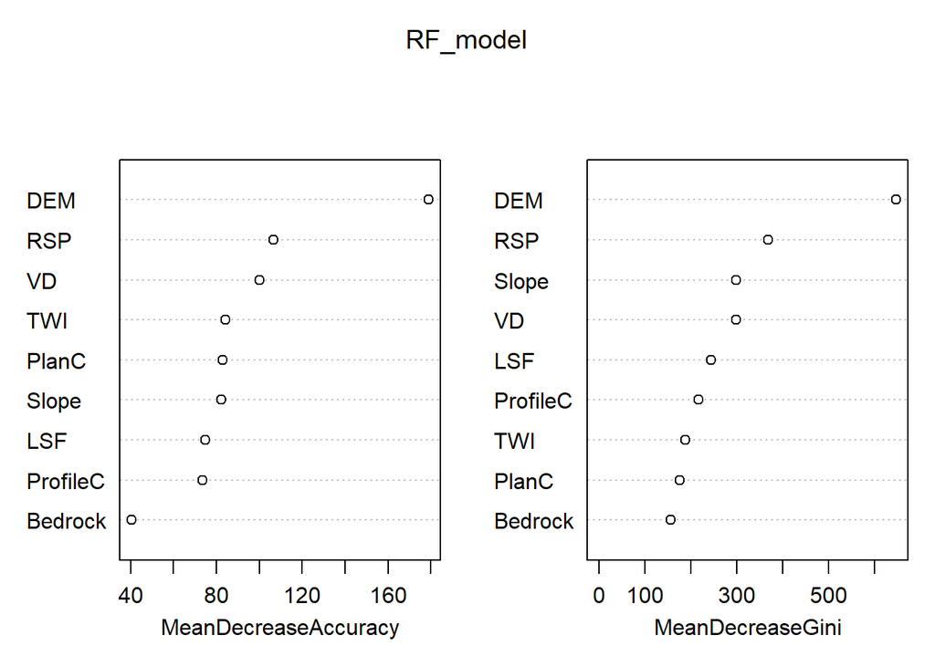

```r
sampleNum_dict[mn]<-nrow(sampData)

sampData$Bedrock<- droplevels(as.factor(sampData$Bedrock))
sampData$soilID<- droplevels(as.factor(sampData$soilID))

RF_model<-randomForest(soilID ~.,data = sampData,
                       importance = TRUE, proximity = FALSE,
                       ntree=1000,type="classification")

varImpPlot(RF_model)
```

```r
print(RF_model)
```

```
##
## Call:
##  randomForest(formula = soilID ~ ., data = sampData, importance = TRUE,      proximity = FALSE, ntree = 1000, type = "classification")
##                Type of random forest: classification
##                      Number of trees: 1000
## No. of variables tried at each split: 3
##
##         OOB estimate of  error rate: 23.67%
## Confusion matrix:
##      1  20 21  23   3 30 31 501 502 503   7 class.error
## 1   14   0  0   0   3  0  0   0   0   0   0   0.1764706
## 20   0 295 36   2   0  0  0   4   2  87  45   0.3736730
## 21   0  68 92   0   0  0  0   1   1   5   3   0.4588235
## 23   0   0  0 231   0  8 10   0   0  31   8   0.1979167
## 3    2   0  0   0 116  0  0  47   0   0   0   0.2969697
## 30   0   0  0  24   0 47 10   0   0   2   8   0.4835165
## 31   0   0  0  18   0  4 96   0   0   2   0   0.2000000
## 501  0   3  0   0  34  0  0 451   0   0  22   0.1156863
## 502  0   4  1   0   0  0  0   0  49   2   4   0.1833333
## 503  0  62  3  37   0  1  0   0   1 599  19   0.1703601
## 7    0  27  2   1   0  1  0  37   3  23 326   0.2238095
```

```r
map_RF <- predict(covStack, RF_model, paste(result_tif_folder,mn,".tif",sep=""),
                  format = "GTiff", datatype = "FLT4S", overwrite = TRUE)

rm("mn","shpPoint","sampData","RF_model","map_RF")
```

## ns5

RANst RSP ns5 15

```r
mn="All_pRANst_RSP_NS5_pen15"

shpPoint<-readOGR(paste(point_shp_folder,mn,".shp",sep = "")) ###
sampData <- extract(covStack, shpPoint, sp = TRUE,method = "simple")

sampData<-sampData@data

sampData<-sampData[sampData$soilID %in% soil_type,]

sampData<-na.omit(sampData)

print(dim(sampData))
```

```
## [1] 355  10
```

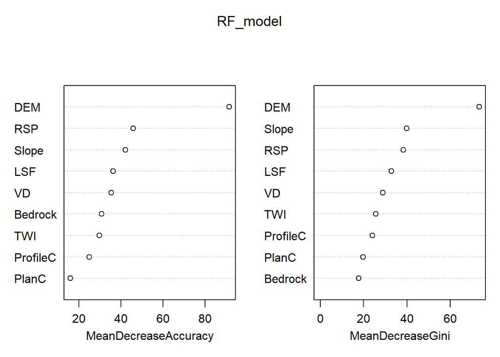

```r
sampleNum_dict[mn]<-nrow(sampData)

sampData$Bedrock<- droplevels(as.factor(sampData$Bedrock))
sampData$soilID<- droplevels(as.factor(sampData$soilID))

RF_model<-randomForest(soilID ~.,data = sampData,
                       importance = TRUE, proximity = FALSE,
                       ntree=1000,type="classification")

varImpPlot(RF_model)
```

```r
print(RF_model)
```

```
##
## Call:
##  randomForest(formula = soilID ~ ., data = sampData, importance = TRUE,      proximity = FALSE, ntree = 1000, type = "classification")
##                Type of random forest: classification
##                      Number of trees: 1000
## No. of variables tried at each split: 3
##
##         OOB estimate of  error rate: 38.03%
## Confusion matrix:
##     1 20 21 23 3 30 31 501 502 503  7 class.error
## 1   0  0  0  0 2  0  0   0   0   0  0   1.0000000
## 20  0 14  5  0 0  0  0   3   0  20  6   0.7083333
## 21  0 13  5  0 0  0  0   0   1   3  0   0.7727273
## 23  0  0  0 20 0  2  2   0   0   4  2   0.3333333
## 3   0  0  0  0 9  0  0  11   0   0  0   0.5500000
## 30  0  0  0  3 0  3  0   0   0   2  0   0.6250000
## 31  0  0  0  6 0  1  5   0   0   1  0   0.6153846
## 501 0  0  0  0 4  0  0  56   1   0  4   0.1384615
## 502 0  1  1  0 0  0  0   2   2   0  1   0.7142857
## 503 0  8  2  6 0  0  0   0   0  66  5   0.2413793
## 7   0  2  0  2 0  0  0   4   0   5 40   0.2452830
```

```r
map_RF <- predict(covStack, RF_model, paste(result_tif_folder,mn,".tif",sep=""),
                  format = "GTiff", datatype = "FLT4S", overwrite = TRUE)

rm("mn","shpPoint","sampData","RF_model","map_RF")
```

RANst RSP ns5 30

```r
mn="All_pRANst_RSP_NS5_pen30"

shpPoint<-readOGR(paste(point_shp_folder,mn,".shp",sep = "")) ###
sampData <- extract(covStack, shpPoint, sp = TRUE,method = "simple")

sampData<-sampData@data

sampData<-sampData[sampData$soilID %in% soil_type,]

sampData<-na.omit(sampData)

print(dim(sampData))
```

```
## [1] 673  10
```

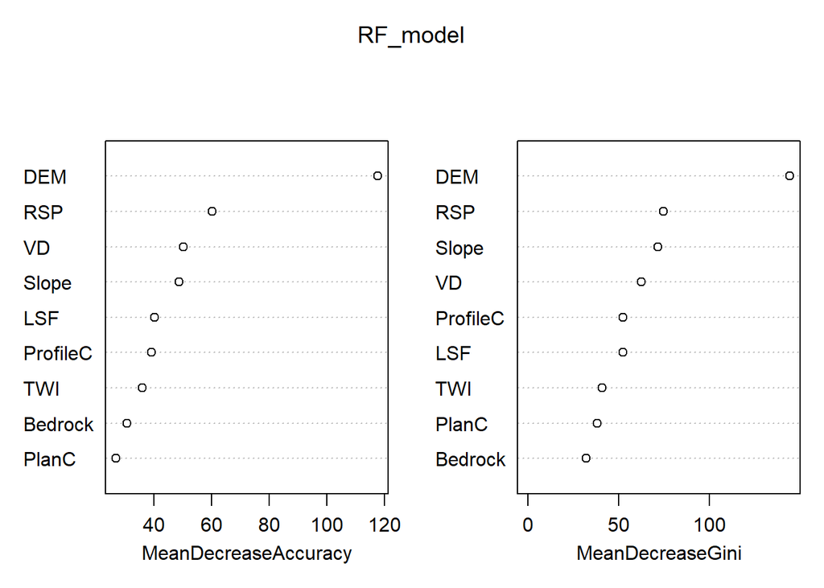

```r
sampleNum_dict[mn]<-nrow(sampData)

sampData$Bedrock<- droplevels(as.factor(sampData$Bedrock))
sampData$soilID<- droplevels(as.factor(sampData$soilID))

RF_model<-randomForest(soilID ~.,data = sampData,
                       importance = TRUE, proximity = FALSE,
                       ntree=1000,type="classification")

varImpPlot(RF_model)
```

```r
print(RF_model)
```

```
##
## Call:
##  randomForest(formula = soilID ~ ., data = sampData, importance = TRUE,      proximity = FALSE, ntree = 1000, type = "classification")
##                Type of random forest: classification
##                      Number of trees: 1000
## No. of variables tried at each split: 3
##
##         OOB estimate of  error rate: 32.99%
## Confusion matrix:
##     1 20 21 23  3 30 31 501 502 503  7 class.error
## 1   0  0  0  0  3  0  0   0   0   0  0   1.0000000
## 20  0 52  8  0  0  0  0   0   1  20  9   0.4222222
## 21  0 13 14  0  0  0  0   0   0   4  2   0.5757576
## 23  0  0  0 22  0  2  7   0   0  19  5   0.6000000
## 3   2  0  0  0 18  0  0  19   0   0  0   0.5384615
## 30  0  0  0  6  0  6  1   0   0   1  1   0.6000000
## 31  0  0  0  6  0  2 16   0   0   2  0   0.3846154
## 501 0  0  0  0 12  0  0 111   0   0  6   0.1395349
## 502 0  1  1  0  0  0  0   5   5   0  2   0.6428571
## 503 0 15  3 11  0  0  0   0   1 132  6   0.2142857
## 7   0  4  0  2  0  0  0  12   1   7 75   0.2574257
```

```r
map_RF <- predict(covStack, RF_model, paste(result_tif_folder,mn,".tif",sep=""),
                  format = "GTiff", datatype = "FLT4S", overwrite = TRUE)

rm("mn","shpPoint","sampData","RF_model","map_RF")
```

RANst RSP ns5 45

```r
mn="All_pRANst_RSP_NS5_pen45"

shpPoint<-readOGR(paste(point_shp_folder,mn,".shp",sep = "")) ###
sampData <- extract(covStack, shpPoint, sp = TRUE,method = "simple")

sampData<-sampData@data

sampData<-sampData[sampData$soilID %in% soil_type,]

sampData<-na.omit(sampData)

print(dim(sampData))
```

```
## [1] 991  10
```

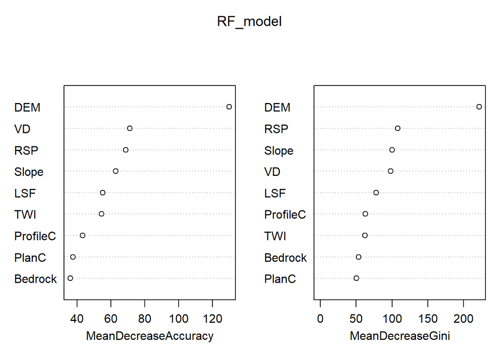

```r
sampleNum_dict[mn]<-nrow(sampData)

sampData$Bedrock<- droplevels(as.factor(sampData$Bedrock))
sampData$soilID<- droplevels(as.factor(sampData$soilID))

RF_model<-randomForest(soilID ~.,data = sampData,
                       importance = TRUE, proximity = FALSE,
                       ntree=1000,type="classification")

varImpPlot(RF_model)
```

```r
print(RF_model)
```

```
##
## Call:
##  randomForest(formula = soilID ~ ., data = sampData, importance = TRUE,      proximity = FALSE, ntree = 1000, type = "classification")
##                Type of random forest: classification
##                      Number of trees: 1000
## No. of variables tried at each split: 3
##
##         OOB estimate of  error rate: 25.43%
## Confusion matrix:
##     1 20 21 23  3 30 31 501 502 503   7 class.error
## 1   1  0  0  0  3  0  0   0   0   0   0   0.7500000
## 20  0 72  8  1  0  0  0   1   1  31  16   0.4461538
## 21  0 16 21  0  0  0  0   0   1   7   0   0.5333333
## 23  0  1  0 58  0  5  3   0   0  11   3   0.2839506
## 3   1  0  0  0 36  0  0  21   0   0   0   0.3793103
## 30  0  0  0  6  0 10  1   0   0   1   2   0.5000000
## 31  0  0  0  5  0  1 32   0   0   1   0   0.1794872
## 501 0  1  0  0 11  0  0 172   0   0   8   0.1041667
## 502 0  1  1  0  0  0  0   1  16   0   2   0.2380952
## 503 0 19  1  9  0  1  0   1   0 210  11   0.1666667
## 7   0 16  0  1  0  2  0  14   0   5 111   0.2550336
```

```r
map_RF <- predict(covStack, RF_model, paste(result_tif_folder,mn,".tif",sep=""),
                  format = "GTiff", datatype = "FLT4S", overwrite = TRUE)

rm("mn","shpPoint","sampData","RF_model","map_RF")
```

## ns7

RANst RSP ns7 15

```r
mn="All_pRANst_RSP_NS7_pen15"

shpPoint<-readOGR(paste(point_shp_folder,mn,".shp",sep = "")) ###
sampData <- extract(covStack, shpPoint, sp = TRUE,method = "simple")

sampData<-sampData@data

sampData<-sampData[sampData$soilID %in% soil_type,]

sampData<-na.omit(sampData)

print(dim(sampData))
```

```
## [1] 127  10
```

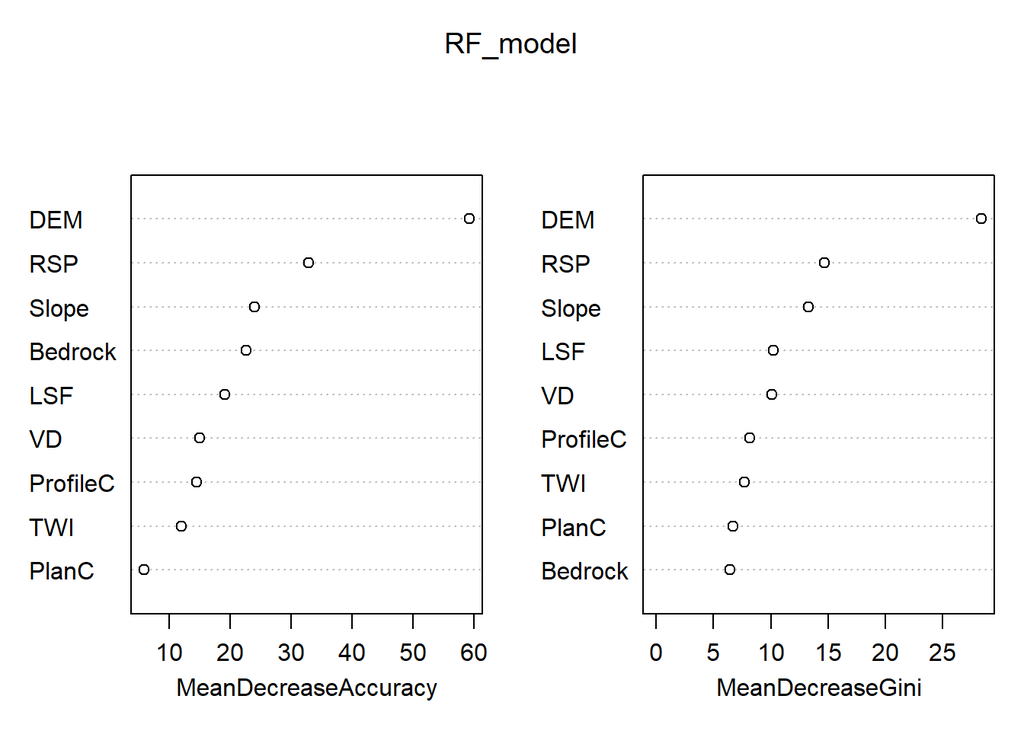

```r
sampleNum_dict[mn]<-nrow(sampData)

sampData$Bedrock<- droplevels(as.factor(sampData$Bedrock))
sampData$soilID<- droplevels(as.factor(sampData$soilID))

RF_model<-randomForest(soilID ~.,data = sampData,
                       importance = TRUE, proximity = FALSE,
                       ntree=1000,type="classification")

varImpPlot(RF_model)
```

```r
print(RF_model)
```

```
##
## Call:
##  randomForest(formula = soilID ~ ., data = sampData, importance = TRUE,      proximity = FALSE, ntree = 1000, type = "classification")
##                Type of random forest: classification
##                      Number of trees: 1000
## No. of variables tried at each split: 3
##
##         OOB estimate of  error rate: 36.22%
## Confusion matrix:
##     1 20 21 23 3 30 31 501 502 503  7 class.error
## 1   0  0  0  0 1  0  0   0   0   0  0  1.00000000
## 20  0  4  1  0 0  0  0   1   1   6  4  0.76470588
## 21  0  2  2  0 0  0  0   0   0   0  0  0.50000000
## 23  0  0  0  7 0  0  0   0   0   3  1  0.36363636
## 3   0  0  0  0 6  0  0   1   0   0  0  0.14285714
## 30  0  0  0  1 0  0  1   0   0   0  0  1.00000000
## 31  0  0  0  2 0  0  1   0   0   1  0  0.75000000
## 501 0  0  0  0 0  0  0  25   0   0  1  0.03846154
## 502 0  2  0  0 0  0  0   1   0   0  0  1.00000000
## 503 0  4  0  2 0  0  0   0   0  24  1  0.22580645
## 7   0  3  0  2 0  0  0   1   0   3 12  0.42857143
```

```r
map_RF <- predict(covStack, RF_model, paste(result_tif_folder,mn,".tif",sep=""),
                  format = "GTiff", datatype = "FLT4S", overwrite = TRUE)

rm("mn","shpPoint","sampData","RF_model","map_RF")
```

RANst RSP ns7 30

```r
mn="All_pRANst_RSP_NS7_pen30"

shpPoint<-readOGR(paste(point_shp_folder,mn,".shp",sep = "")) ###
sampData <- extract(covStack, shpPoint, sp = TRUE,method = "simple")

sampData<-sampData@data

sampData<-sampData[sampData$soilID %in% soil_type,]

sampData<-na.omit(sampData)

print(dim(sampData))
```

```
## [1] 226  10
```

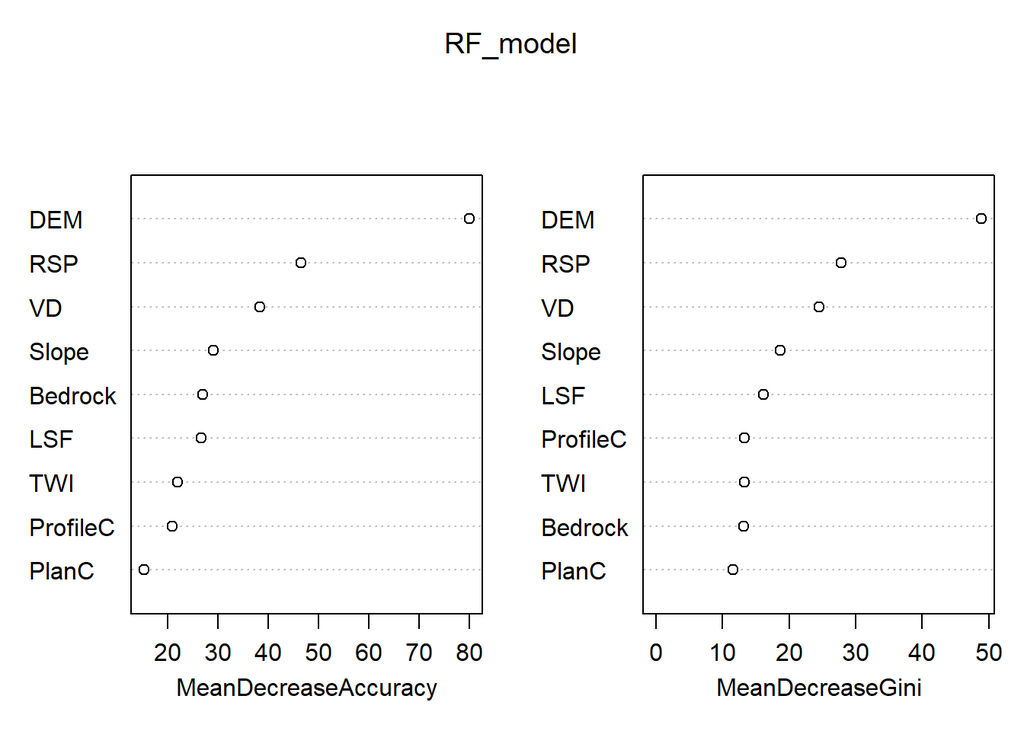

```r
sampleNum_dict[mn]<-nrow(sampData)

sampData$Bedrock<- droplevels(as.factor(sampData$Bedrock))
sampData$soilID<- droplevels(as.factor(sampData$soilID))

RF_model<-randomForest(soilID ~.,data = sampData,
                       importance = TRUE, proximity = FALSE,
                       ntree=1000,type="classification")

varImpPlot(RF_model)
```

```r
print(RF_model)
```

```
##
## Call:
##  randomForest(formula = soilID ~ ., data = sampData, importance = TRUE,      proximity = FALSE, ntree = 1000, type = "classification")
##                Type of random forest: classification
##                      Number of trees: 1000
## No. of variables tried at each split: 3
##
##         OOB estimate of  error rate: 30.53%
## Confusion matrix:
##     1 20 21 23 3 30 31 501 502 503  7 class.error
## 1   0  0  0  0 1  0  0   0   0   0  0   1.0000000
## 20  0 13  1  0 0  0  0   0   0   8  5   0.5185185
## 21  0  2  1  0 0  0  0   0   0   3  0   0.8333333
## 23  0  0  0 12 0  1  2   0   0   5  0   0.4000000
## 3   1  0  0  0 7  0  0   5   0   0  0   0.4615385
## 30  0  0  0  3 0  0  0   0   0   0  0   1.0000000
## 31  0  0  0  3 0  0  4   0   0   0  0   0.4285714
## 501 0  0  0  0 2  0  0  46   0   0  2   0.0800000
## 502 0  2  0  0 0  0  0   2   0   1  0   1.0000000
## 503 0  7  0  3 0  0  0   1   0  45  1   0.2105263
## 7   0  2  0  1 0  0  0   3   0   2 29   0.2162162
```

```r
map_RF <- predict(covStack, RF_model, paste(result_tif_folder,mn,".tif",sep=""),
                  format = "GTiff", datatype = "FLT4S", overwrite = TRUE)

rm("mn","shpPoint","sampData","RF_model","map_RF")
```

RANst RSP ns7 45

```r
mn="All_pRANst_RSP_NS7_pen45"

shpPoint<-readOGR(paste(point_shp_folder,mn,".shp",sep = "")) ###
sampData <- extract(covStack, shpPoint, sp = TRUE,method = "simple")

sampData<-sampData@data

sampData<-sampData[sampData$soilID %in% soil_type,]

sampData<-na.omit(sampData)

print(dim(sampData))
```

```
## [1] 321  10
```

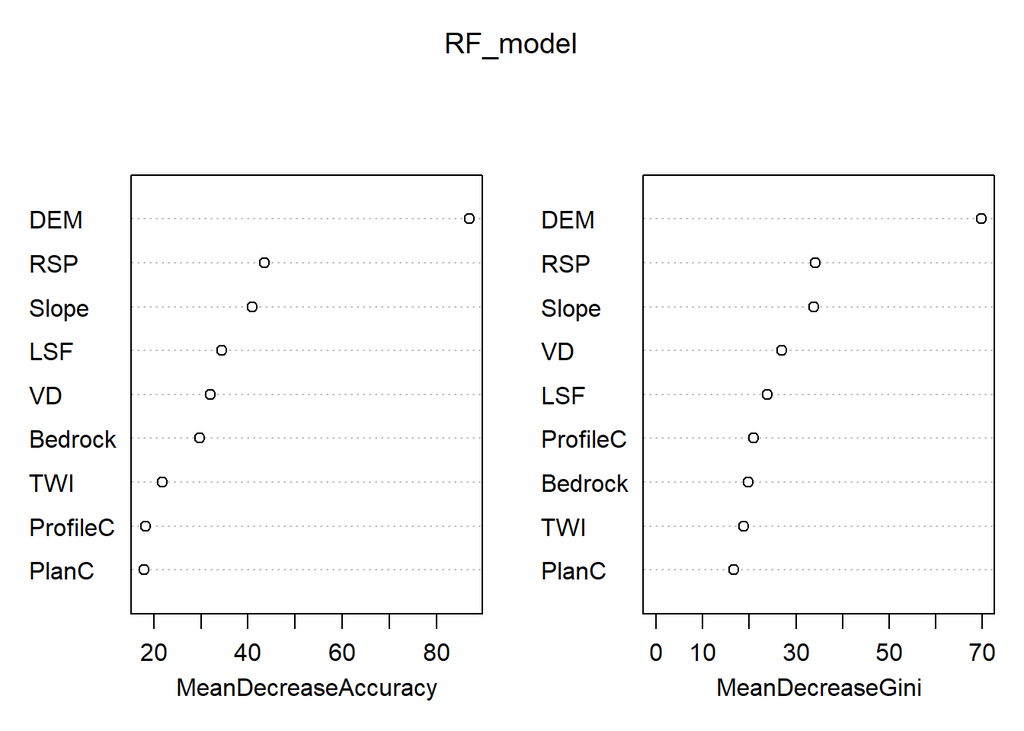

```r
sampleNum_dict[mn]<-nrow(sampData)

sampData$Bedrock<- droplevels(as.factor(sampData$Bedrock))
sampData$soilID<- droplevels(as.factor(sampData$soilID))

RF_model<-randomForest(soilID ~.,data = sampData,
                       importance = TRUE, proximity = FALSE,
                       ntree=1000,type="classification")

varImpPlot(RF_model)
```

```r
print(RF_model)
```

```
##
## Call:
##  randomForest(formula = soilID ~ ., data = sampData, importance = TRUE,      proximity = FALSE, ntree = 1000, type = "classification")
##                Type of random forest: classification
##                      Number of trees: 1000
## No. of variables tried at each split: 3
##
##         OOB estimate of  error rate: 32.4%
## Confusion matrix:
##     1 20 21 23 3 30 31 501 502 503  7 class.error
## 1   0  0  0  0 1  0  0   0   0   0  0   1.0000000
## 20  0 18  1  1 0  0  0   1   0  10  5   0.5000000
## 21  0  7  0  0 0  0  0   0   0   1  0   1.0000000
## 23  0  0  0 17 0  0  2   0   0   7  2   0.3928571
## 3   0  0  0  0 9  0  0  10   0   0  0   0.5263158
## 30  0  0  0  2 0  0  1   0   0   0  1   1.0000000
## 31  0  0  0  3 0  1  6   0   0   0  0   0.4000000
## 501 0  0  0  0 8  0  0  63   0   0  4   0.1600000
## 502 0  1  0  0 0  0  0   3   0   0  2   1.0000000
## 503 0  4  1  5 0  0  0   0   0  71  2   0.1445783
## 7   0  4  0  2 0  1  0   3   0   8 33   0.3529412
```

```r
map_RF <- predict(covStack, RF_model, paste(result_tif_folder,mn,".tif",sep=""),
                  format = "GTiff", datatype = "FLT4S", overwrite = TRUE)

rm("mn","shpPoint","sampData","RF_model","map_RF")
```

## 精度计算

```r
#设置最终结果tif的保存路径
result_tif_folder="E:/soilPaper/modling/result_mapTif/"

result_map_name<-c("All_pRANst_DEM_NS3_pen15","All_pRANst_DEM_NS5_pen15","All_pRANst_DEM_NS7_pen15",
                   "All_pRANst_DEM_NS3_pen30","All_pRANst_DEM_NS5_pen30","All_pRANst_DEM_NS7_pen30",
                   "All_pRANst_DEM_NS3_pen45","All_pRANst_DEM_NS5_pen45","All_pRANst_DEM_NS7_pen45",
                   "All_pRANst_Slope_NS3_pen15","All_pRANst_Slope_NS5_pen15","All_pRANst_Slope_NS7_pen15",
                   "All_pRANst_Slope_NS3_pen30","All_pRANst_Slope_NS5_pen30","All_pRANst_Slope_NS7_pen30",
                   "All_pRANst_Slope_NS3_pen45","All_pRANst_Slope_NS5_pen45","All_pRANst_Slope_NS7_pen45",
                   "All_pRANst_PlanC_NS3_pen15","All_pRANst_PlanC_NS5_pen15","All_pRANst_PlanC_NS7_pen15",
                   "All_pRANst_PlanC_NS3_pen30","All_pRANst_PlanC_NS5_pen30","All_pRANst_PlanC_NS7_pen30",
                   "All_pRANst_PlanC_NS3_pen45","All_pRANst_PlanC_NS5_pen45","All_pRANst_PlanC_NS7_pen45",
                   "All_pRANst_ProfileC_NS3_pen15","All_pRANst_ProfileC_NS5_pen15","All_pRANst_ProfileC_NS7_pen15",
                   "All_pRANst_ProfileC_NS3_pen30","All_pRANst_ProfileC_NS5_pen30","All_pRANst_ProfileC_NS7_pen30",
                   "All_pRANst_ProfileC_NS3_pen45","All_pRANst_ProfileC_NS5_pen45","All_pRANst_ProfileC_NS7_pen45",
                   "All_pRANst_TWI_NS3_pen15","All_pRANst_TWI_NS5_pen15","All_pRANst_TWI_NS7_pen15",
                   "All_pRANst_TWI_NS3_pen30","All_pRANst_TWI_NS5_pen30","All_pRANst_TWI_NS7_pen30",
                   "All_pRANst_TWI_NS3_pen45","All_pRANst_TWI_NS5_pen45","All_pRANst_TWI_NS7_pen45",
                   "All_pRANst_LSF_NS3_pen15","All_pRANst_LSF_NS5_pen15","All_pRANst_LSF_NS7_pen15",
                   "All_pRANst_LSF_NS3_pen30","All_pRANst_LSF_NS5_pen30","All_pRANst_LSF_NS7_pen30",
                   "All_pRANst_LSF_NS3_pen45","All_pRANst_LSF_NS5_pen45","All_pRANst_LSF_NS7_pen45",
                   "All_pRANst_VD_NS3_pen15","All_pRANst_VD_NS5_pen15","All_pRANst_VD_NS7_pen15",
                   "All_pRANst_VD_NS3_pen30","All_pRANst_VD_NS5_pen30","All_pRANst_VD_NS7_pen30",
                   "All_pRANst_VD_NS3_pen45","All_pRANst_VD_NS5_pen45","All_pRANst_VD_NS7_pen45",
                   "All_pRANst_RSP_NS3_pen15","All_pRANst_RSP_NS5_pen15","All_pRANst_RSP_NS7_pen15",
                   "All_pRANst_RSP_NS3_pen30","All_pRANst_RSP_NS5_pen30","All_pRANst_RSP_NS7_pen30",
                   "All_pRANst_RSP_NS3_pen45","All_pRANst_RSP_NS5_pen45","All_pRANst_RSP_NS7_pen45")

resultCovStack<-raster(paste(result_tif_folder,result_map_name[1],".tif",sep = ""))
for (i in 2:length(result_map_name)) {
  resultCovStack <- stack(resultCovStack, raster(paste(result_tif_folder,result_map_name[i],".tif",sep = "")))
}

validationPoint<-readOGR(paste(result_tif_folder,"validationPoint.shp",sep = "")) ###
vp_data <- extract(resultCovStack, validationPoint, sp = TRUE,method = "simple")
vp_data<-na.omit(vp_data@data)


vp_data<-vp_data[vp_data$trueType %in% soil_type,]

print(nrow(vp_data))
```

```
## [1] 90
```

```r
precision_df<-data.frame("method"=rep(NA,length(result_map_name)),
                         "factor"=rep(NA,length(result_map_name)),
                         "NS"=rep(NA,length(result_map_name)),
                         "percent"=rep(NA,length(result_map_name)),
                         "precisionValue"=rep(NA,length(result_map_name)),
                         "sampleNum"=rep(NA,length(result_map_name)))

for (i in 1:length(result_map_name)){
  fna<-result_map_name[i]
  ns_split<-unlist(strsplit(fna,"_"))
  if (length(ns_split)==5){
    precision_df[i,]$method<-ns_split[2]
    precision_df[i,]$factor<-ns_split[3]
    precision_df[i,]$NS<-ns_split[4]
    precision_df[i,]$percent<-ns_split[5]
    precision_df[i,]$precisionValue<-round( sum(vp_data$trueType==vp_data[fna])/nrow(vp_data),4)
    precision_df[i,]$sampleNum<-as.vector(unlist(sampleNum_dict[fna]))
  }

}

precision_oldSoilMap<-round( sum(vp_data$trueType==vp_data$oldSoilMap)/nrow(vp_data),4)
print(precision_oldSoilMap)
```

```
## [1] 0.6333
```

```r
print(precision_df)
```

```
##    method   factor  NS percent precisionValue sampleNum
## 1  pRANst      DEM NS3   pen15         0.7000      1042
## 2  pRANst      DEM NS5   pen15         0.5556       355
## 3  pRANst      DEM NS7   pen15         0.6333       131
## 4  pRANst      DEM NS3   pen30         0.6333      2043
## 5  pRANst      DEM NS5   pen30         0.6000       679
## 6  pRANst      DEM NS7   pen30         0.6111       227
## 7  pRANst      DEM NS3   pen45         0.6889      3038
## 8  pRANst      DEM NS5   pen45         0.6556       995
## 9  pRANst      DEM NS7   pen45         0.6222       327
## 10 pRANst    Slope NS3   pen15         0.6333       996
## 11 pRANst    Slope NS5   pen15         0.6556       336
## 12 pRANst    Slope NS7   pen15         0.5444       121
## 13 pRANst    Slope NS3   pen30         0.6667      1948
## 14 pRANst    Slope NS5   pen30         0.6556       636
```

[output cut: 58 more lines]

```r
write.csv(precision_df,"结果精度_随机土壤类型_origin.csv",row.names = F,fileEncoding="utf-8")



pdf_ran<-subset(precision_df,method=="pRANst")

pdf_ran_mean<-aggregate(pdf_ran[,c("precisionValue","sampleNum")],by=list(method=pdf_ran$method,NS=pdf_ran$NS,percent=pdf_ran$percent),FUN=mean)
pdf_ran_mean$factor<-"Random"

precision_df_final<-pdf_ran_mean
print(precision_df_final)
```

```
##   method  NS percent precisionValue sampleNum factor
## 1 pRANst NS3   pen15      0.6694375  1011.875 Random
## 2 pRANst NS5   pen15      0.5944625   344.500 Random
## 3 pRANst NS7   pen15      0.5999750   141.250 Random
## 4 pRANst NS3   pen30      0.6527750  1978.875 Random
## 5 pRANst NS5   pen30      0.6513750   651.375 Random
## 6 pRANst NS7   pen30      0.5902750   221.125 Random
## 7 pRANst NS3   pen45      0.6625000  2942.750 Random
## 8 pRANst NS5   pen45      0.6333375   957.375 Random
## 9 pRANst NS7   pen45      0.5999875   315.500 Random
```

```r
write.csv(precision_df_final,"结果精度_随机土壤类型_final.csv",row.names = F,fileEncoding="utf-8")
```